# XGboost

610811101

2020/7/15

# 資料生成跑XGboost Feature Importances

## 資料一 (部分相關)

就算只有一部分資料是相關的，XGboost的成效會仍然會變差。

$x_{1 \sim 5}\sim MN(\mu_1 , \Sigma_1 )$  
$\mu_1=(0,0,0,0,0,0,0,0,0,0)$  
$\Sigma_1 = A^TDA$

$$D = \begin{pmatrix}
1 & 0 & 0 & 0 & 0 \\
0 & 1& 0 & 0 & 0 \\
0 & 0& 1 & 0 & 0 \\
0 & 0& 0 & 1 & 0 \\
0 & 0& 0 & 0 & 1
\end{pmatrix}$$

$$A = \begin{pmatrix}
0 & 2 & 2 & -2 & -1 \\
0 & 1& 0 & -2 & -2 \\
-1 & -2& 0 & 2 & 0 \\
-1 & -1& -2 & 0 & 1 \\
0 & 0& 1 & -1 & -2
\end{pmatrix}$$

$x_{6 \sim 10}\sim MN(\mu_2 , \Sigma_2 )$  
$\mu_2=(0,0,0,0,0,0,0,0,0,0)$

$$\Sigma_2 = \begin{pmatrix}
1 & 0 & 0 & 0 & 0 \\
0 & 1& 0 & 0 & 0 \\
0 & 0& 1 & 0 & 0 \\
0 & 0& 0 & 1 & 0 \\
0 & 0& 0 & 0 & 1
\end{pmatrix}$$

$x_{11} \sim N(0,1)$

$y=10x_1+5x_2-3x_3+4x_4+8x_5+10x_6+5x_7-3x_8+4x_9+8x_{10}+\epsilon$

$\epsilon \sim N(0,4)$

### 第一次

```r
set.seed(123)
a <- matrix(sample(-2:2,25,replace = T),5,5)
sigmas <- t(a)%*%diag(1,5)%*%a
set.seed(1253)
x <- rmvnorm(n = 1000,mean = c(0,0,0,0,0),sigma = sigmas)
set.seed(173)
x2 <- rmvnorm(n = 1000,mean = c(0,0,0,0,0),sigma = diag(1,5))
set.seed(59)
x_11 <- rnorm(n = 1000)
set.seed(5)
sd <- rnorm(1000,sd = 2)
y <- 10*x[,1]+5*x[,2]-3*x[,3]+4*x[,4]+8*x[,5]+10*x2[,1]+5*x2[,2]-3*x2[,3]+4*x2[,4]+8*x2[,5]+sd
sim <- data.frame(y,x,x2,x_11)


set.seed(192753)
x <- rmvnorm(n = 1000,mean = c(0,0,0,0,0),sigma = sigmas)
set.seed(1783)
x2 <- rmvnorm(n = 1000,mean = c(0,0,0,0,0),sigma = diag(1,5))
set.seed(599)
x_11 <- rnorm(n = 1000)
set.seed(54)
sd <- rnorm(1000,sd = 2)
y <- 10*x[,1]+5*x[,2]-3*x[,3]+4*x[,4]+8*x[,5]+10*x2[,1]+5*x2[,2]-3*x2[,3]+4*x2[,4]+8*x2[,5]+sd
sim_2 <- data.frame(y,x,x2,x_11)
names(sim) <- c("y",paste0("x",1:11))
names(sim_2) <- c("y",paste0("x",1:11))
print("直接將生成的資料放進回歸中測試")
```

```
## [1] "直接將生成的資料放進回歸中測試"
```

```r
lm(y~.,data = sim) %>% summary()
```

```
##
## Call:
## lm(formula = y ~ ., data = sim)
##
## Residuals:
##    Min     1Q Median     3Q    Max
## -6.832 -1.357  0.032  1.346  6.432
##
## Coefficients:
##             Estimate Std. Error t value Pr(>|t|)
## (Intercept)  0.02948    0.06404   0.460    0.645
## x1           9.89062    0.09322 106.101   <2e-16 ***
## x2           4.97839    0.14304  34.804   <2e-16 ***
## x3          -2.92245    0.06432 -45.438   <2e-16 ***
## x4           3.98587    0.11789  33.810   <2e-16 ***
## x5           8.03210    0.07080 113.453   <2e-16 ***
## x6           9.92481    0.06591 150.592   <2e-16 ***
## x7           5.04741    0.06553  77.022   <2e-16 ***
## x8          -2.96479    0.06207 -47.764   <2e-16 ***
## x9           4.08446    0.06264  65.210   <2e-16 ***
## x10          7.88316    0.06159 128.002   <2e-16 ***
## x11         -0.01318    0.06355  -0.207    0.836
## ---
## Signif. codes:  0 '***' 0.001 '**' 0.01 '*' 0.05 '.' 0.1 ' ' 1
##
## Residual standard error: 2.02 on 988 degrees of freedom
## Multiple R-squared:  0.9972, Adjusted R-squared:  0.9972
## F-statistic: 3.182e+04 on 11 and 988 DF,  p-value: < 2.2e-16
```

```r
label  <- lm(y~.,data = sim) %>% predict(sim_2)
print("MSE")
```

```
## [1] "MSE"
```

```r
mean((sim_2$y-label)^2)
```

```
## [1] 4.309476
```

```r
print("xgboost")
```

```
## [1] "xgboost"
```

```r
xgb_test <- xgboost(data = data.matrix(sim[,-1]),
label = sim[,"y"],
eta = 0.5,
max_depth = 10,
nround=25,
subsample = 0.7,
colsample_bytree = 0.7,
objective = "reg:squarederror",
verbose = 0
)
label  <- predict(xgb_test,xgb.DMatrix(data.matrix(sim_2[,-1])))
print("MSE")
```

```
## [1] "MSE"
```

```r
mean((sim_2$y-label)^2)
```

```
## [1] 212.4761
```

```r
xgb.importance(model = xgb_test)
```

| Feature | Gain | Cover | Frequency |
| --- | --- | --- | --- |
| x5 | 0.662090389 | 0.12467962 | 0.08451503 |
| x2 | 0.084776470 | 0.10712552 | 0.16931367 |
| x6 | 0.071432275 | 0.10296441 | 0.09982984 |
| x10 | 0.050196115 | 0.09861891 | 0.07997731 |
| x1 | 0.027111317 | 0.10601916 | 0.13386273 |
| x7 | 0.023406811 | 0.06256415 | 0.06125922 |
| x9 | 0.020063028 | 0.09559488 | 0.08054453 |
| x3 | 0.018885829 | 0.09279827 | 0.10635281 |
| x4 | 0.018464001 | 0.07107691 | 0.06920023 |
| x11 | 0.014967217 | 0.05880871 | 0.05388542 |

[output cut: 1 more lines]

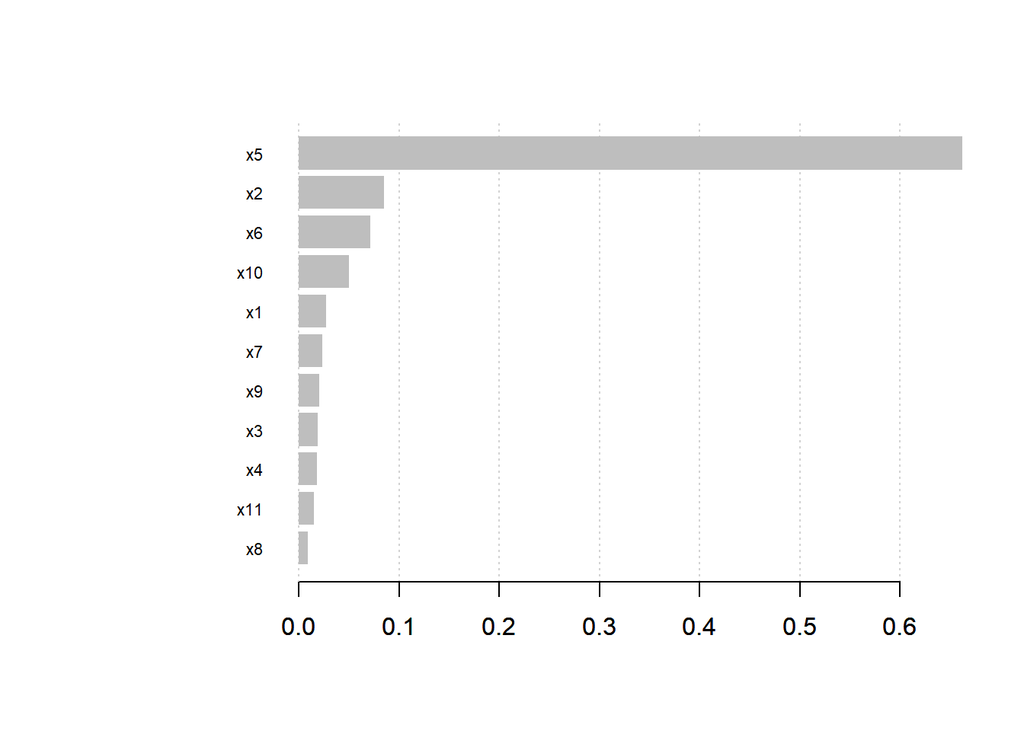

```r
xgb.importance(model = xgb_test) %>%
  xgb.plot.importance(top_n = 11)
```

```r
sim$y <- ifelse(sim$y>0,1,0)
sim_2$y <- ifelse(sim_2$y>0,1,0)
glm(y~.,family = binomial(),data = sim) %>% summary()
```

```
##
## Call:
## glm(formula = y ~ ., family = binomial(), data = sim)
##
## Deviance Residuals:
##    Min      1Q  Median      3Q     Max
## -2.802   0.000   0.000   0.000   2.197
##
## Coefficients:
##             Estimate Std. Error z value Pr(>|z|)
## (Intercept)  0.37857    0.53857   0.703 0.482104
## x1          15.46431    4.27094   3.621 0.000294 ***
## x2           8.49811    2.33689   3.637 0.000276 ***
## x3          -5.03409    1.41789  -3.550 0.000385 ***
## x4           6.25114    1.74231   3.588 0.000333 ***
## x5          14.05594    3.92110   3.585 0.000337 ***
## x6          16.10731    4.25629   3.784 0.000154 ***
## x7           8.50072    2.36282   3.598 0.000321 ***
## x8          -4.30577    1.17265  -3.672 0.000241 ***
## x9           6.60321    1.81349   3.641 0.000271 ***
## x10         13.52153    3.70683   3.648 0.000265 ***
## x11         -0.05661    0.52548  -0.108 0.914211
## ---
## Signif. codes:  0 '***' 0.001 '**' 0.01 '*' 0.05 '.' 0.1 ' ' 1
##
## (Dispersion parameter for binomial family taken to be 1)
##
##     Null deviance: 1386.278  on 999  degrees of freedom
## Residual deviance:   35.867  on 988  degrees of freedom
## AIC: 59.867
##
## Number of Fisher Scoring iterations: 14
```

```r
label  <- glm(y~.,family = binomial(),data = sim) %>% predict(sim_2,type="response")
```

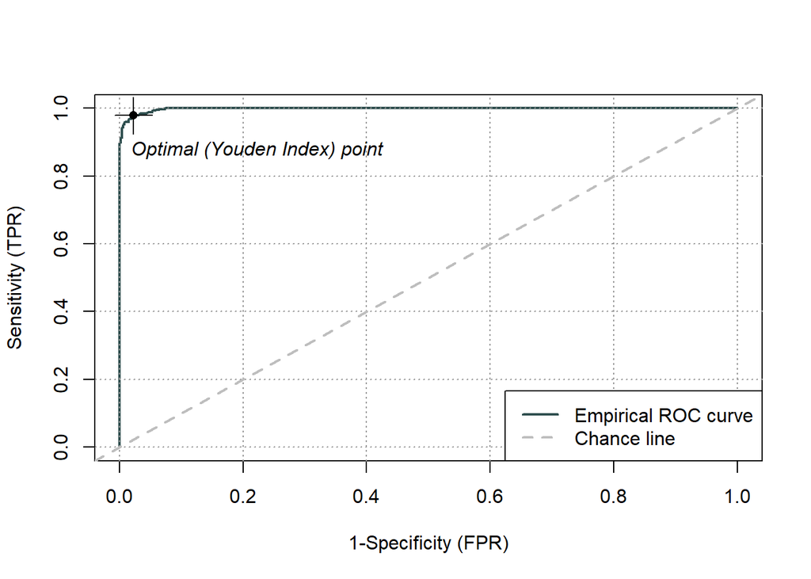

```r
Roc <- rocit(score=label,class=sim_2$y )

plot(Roc,values=F)
```

```r
Cutoff <- which(Roc$FPR>=0.03) %>%
  min %>%
  Roc$Cutoff[.]
table(sim_2$y,label>Cutoff)
```

```
##
##     FALSE TRUE
##   0   474   14
##   1    11  501
```

```r
print("xgboost")
```

```
## [1] "xgboost"
```

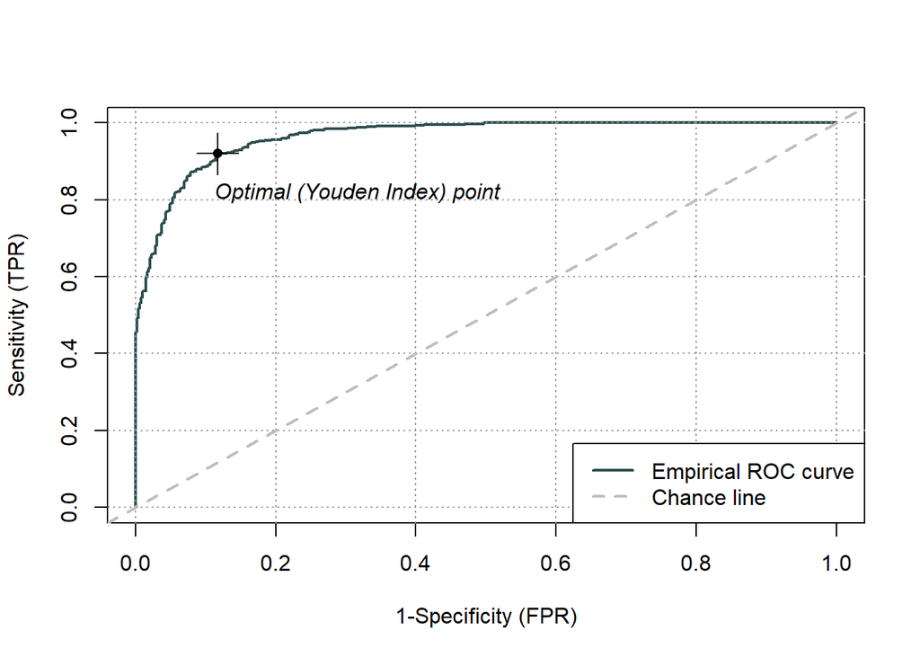

```r
xgb_test <- xgboost(data = data.matrix(sim[,-1]),
label = sim[,"y"],
eta = 0.5,
max_depth = 10,
nround=25,
subsample = 0.7,
colsample_bytree = 0.7,
objective = "binary:logistic",
verbose = 0
)
label  <- predict(xgb_test,xgb.DMatrix(data.matrix(sim_2[,-1])))
Roc <- rocit(score=label,class=sim_2$y )

plot(Roc,values=F)
```

```r
Cutoff <- which(Roc$FPR>=0.1) %>%
  min %>%
  Roc$Cutoff[.]

table(sim_2$y,label>Cutoff)
```

```
##
##     FALSE TRUE
##   0   440   48
##   1    58  454
```

```r
xgb.importance(model = xgb_test)
```

| Feature | Gain | Cover | Frequency |
| --- | --- | --- | --- |
| x5 | 0.35704598 | 0.18303210 | 0.11092150 |
| x2 | 0.12734325 | 0.10711212 | 0.13651877 |
| x10 | 0.10564629 | 0.13670731 | 0.12627986 |
| x1 | 0.08677938 | 0.11395220 | 0.09385666 |
| x4 | 0.07388700 | 0.08901751 | 0.07508532 |
| x6 | 0.06253775 | 0.08605360 | 0.06143345 |
| x7 | 0.05819784 | 0.09096874 | 0.09044369 |
| x9 | 0.04582953 | 0.06713220 | 0.10238908 |
| x11 | 0.03536385 | 0.03753187 | 0.08191126 |
| x8 | 0.02847347 | 0.04943776 | 0.06996587 |

[output cut: 1 more lines]

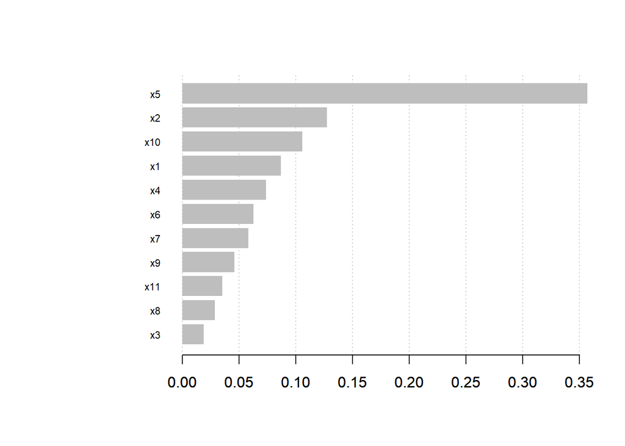

```r
xgb.importance(model = xgb_test) %>%
  xgb.plot.importance(top_n = 11)
```

### 第二次

```r
set.seed(123)
a <- matrix(sample(-2:2,25,replace = T),5,5)
sigmas <- t(a)%*%diag(1,5)%*%a
set.seed(155253)
x <- rmvnorm(n = 1000,mean = c(0,0,0,0,0),sigma = sigmas)
set.seed(6173)
x2 <- rmvnorm(n = 1000,mean = c(0,0,0,0,0),sigma = diag(1,5))
set.seed(579)
x_11 <- rnorm(n = 1000)
set.seed(85)
sd <- rnorm(1000,sd = 2)
y <- 10*x[,1]+5*x[,2]-3*x[,3]+4*x[,4]+8*x[,5]+10*x2[,1]+5*x2[,2]-3*x2[,3]+4*x2[,4]+8*x2[,5]+sd
sim <- data.frame(y,x,x2,x_11)


set.seed(19923)
x <- rmvnorm(n = 1000,mean = c(0,0,0,0,0),sigma = sigmas)
set.seed(175483)
x2 <- rmvnorm(n = 1000,mean = c(0,0,0,0,0),sigma = diag(1,5))
set.seed(5969)
x_11 <- rnorm(n = 1000)
set.seed(547)
sd <- rnorm(1000,sd = 2)
y <- 10*x[,1]+5*x[,2]-3*x[,3]+4*x[,4]+8*x[,5]+10*x2[,1]+5*x2[,2]-3*x2[,3]+4*x2[,4]+8*x2[,5]+sd
sim_2 <- data.frame(y,x,x2,x_11)
names(sim) <- c("y",paste0("x",1:11))
names(sim_2) <- c("y",paste0("x",1:11))
print("直接將生成的資料放進回歸中測試")
```

```
## [1] "直接將生成的資料放進回歸中測試"
```

```r
lm(y~.,data = sim) %>% summary()
```

```
##
## Call:
## lm(formula = y ~ ., data = sim)
##
## Residuals:
##     Min      1Q  Median      3Q     Max
## -5.3408 -1.3408 -0.0721  1.3689  8.1042
##
## Coefficients:
##             Estimate Std. Error t value Pr(>|t|)
## (Intercept) -0.22615    0.06314  -3.582 0.000358 ***
## x1           9.99581    0.09285 107.655  < 2e-16 ***
## x2           5.02397    0.13931  36.064  < 2e-16 ***
## x3          -3.02340    0.06275 -48.180  < 2e-16 ***
## x4           3.97631    0.11616  34.231  < 2e-16 ***
## x5           7.99634    0.06934 115.321  < 2e-16 ***
## x6          10.03562    0.06187 162.204  < 2e-16 ***
## x7           4.94438    0.06425  76.952  < 2e-16 ***
## x8          -3.03731    0.06368 -47.696  < 2e-16 ***
## x9           3.97902    0.06477  61.435  < 2e-16 ***
## x10          7.93819    0.06532 121.525  < 2e-16 ***
## x11          0.01306    0.06427   0.203 0.839007
## ---
## Signif. codes:  0 '***' 0.001 '**' 0.01 '*' 0.05 '.' 0.1 ' ' 1
##
## Residual standard error: 1.987 on 988 degrees of freedom
## Multiple R-squared:  0.9973, Adjusted R-squared:  0.9972
## F-statistic: 3.291e+04 on 11 and 988 DF,  p-value: < 2.2e-16
```

```r
label  <- lm(y~.,data = sim) %>% predict(sim_2)
print("MSE")
```

```
## [1] "MSE"
```

```r
mean((sim_2$y-label)^2)
```

```
## [1] 4.083008
```

```r
print("xgboost")
```

```
## [1] "xgboost"
```

```r
xgb_test <- xgboost(data = data.matrix(sim[,-1]),
label = sim[,"y"],
eta = 0.5,
max_depth = 10,
nround=25,
subsample = 0.7,
colsample_bytree = 0.7,
objective = "reg:squarederror",
verbose = 0
)
label  <- predict(xgb_test,xgb.DMatrix(data.matrix(sim_2[,-1])))
print("MSE")
```

```
## [1] "MSE"
```

```r
mean((sim_2$y-label)^2)
```

```
## [1] 249.2551
```

```r
xgb.importance(model = xgb_test)
```

| Feature | Gain | Cover | Frequency |
| --- | --- | --- | --- |
| x5 | 0.48551438 | 0.13521393 | 0.08314917 |
| x1 | 0.10802495 | 0.14279891 | 0.20718232 |
| x3 | 0.08924220 | 0.05925917 | 0.07762431 |
| x10 | 0.06242593 | 0.10665291 | 0.05745856 |
| x6 | 0.06069699 | 0.07067369 | 0.06491713 |
| x2 | 0.05043085 | 0.08882081 | 0.13701657 |
| x4 | 0.04519839 | 0.08798695 | 0.08066298 |
| x7 | 0.03713777 | 0.07294054 | 0.08121547 |
| x8 | 0.02552845 | 0.08182262 | 0.08093923 |
| x9 | 0.02204612 | 0.07502208 | 0.06215470 |

[output cut: 1 more lines]

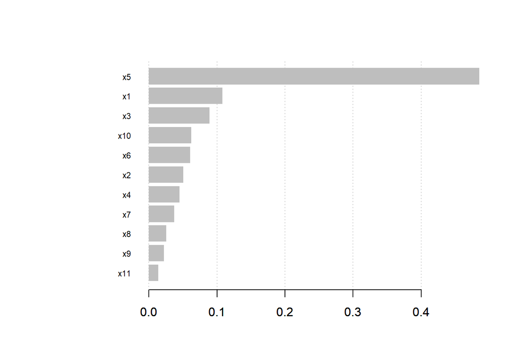

```r
xgb.importance(model = xgb_test) %>%
  xgb.plot.importance(top_n = 11)
```

```r
sim$y <- ifelse(sim$y>0,1,0)
sim_2$y <- ifelse(sim_2$y>0,1,0)
glm(y~.,family = binomial(),data = sim) %>% summary()
```

```
##
## Call:
## glm(formula = y ~ ., family = binomial(), data = sim)
##
## Deviance Residuals:
##    Min      1Q  Median      3Q     Max
## -2.393   0.000   0.000   0.000   2.423
##
## Coefficients:
##             Estimate Std. Error z value Pr(>|z|)
## (Intercept)  -0.7945     0.3897  -2.039 0.041473 *
## x1           12.3066     2.7586   4.461 8.15e-06 ***
## x2            6.9265     1.7913   3.867 0.000110 ***
## x3           -4.0105     1.0126  -3.960 7.48e-05 ***
## x4            5.2990     1.4188   3.735 0.000188 ***
## x5           10.3172     2.2679   4.549 5.39e-06 ***
## x6           12.6303     2.7408   4.608 4.06e-06 ***
## x7            7.0851     1.6312   4.343 1.40e-05 ***
## x8           -3.6732     0.8446  -4.349 1.37e-05 ***
## x9            4.7260     1.1024   4.287 1.81e-05 ***
## x10          10.5382     2.3560   4.473 7.72e-06 ***
## x11           0.1489     0.3578   0.416 0.677343
## ---
## Signif. codes:  0 '***' 0.001 '**' 0.01 '*' 0.05 '.' 0.1 ' ' 1
##
## (Dispersion parameter for binomial family taken to be 1)
##
##     Null deviance: 1385.718  on 999  degrees of freedom
## Residual deviance:   57.704  on 988  degrees of freedom
## AIC: 81.704
##
## Number of Fisher Scoring iterations: 13
```

```r
label  <- glm(y~.,family = binomial(),data = sim) %>% predict(sim_2,type="response")
```

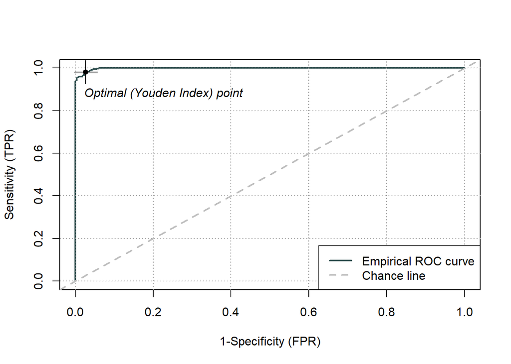

```r
Roc <- rocit(score=label,class=sim_2$y )

plot(Roc,values=F)
```

```r
Cutoff <- which(Roc$FPR>=0.03) %>%
  min %>%
  Roc$Cutoff[.]
table(sim_2$y,label>Cutoff)
```

```
##
##     FALSE TRUE
##   0   508   15
##   1     9  468
```

```r
print("xgboost")
```

```
## [1] "xgboost"
```

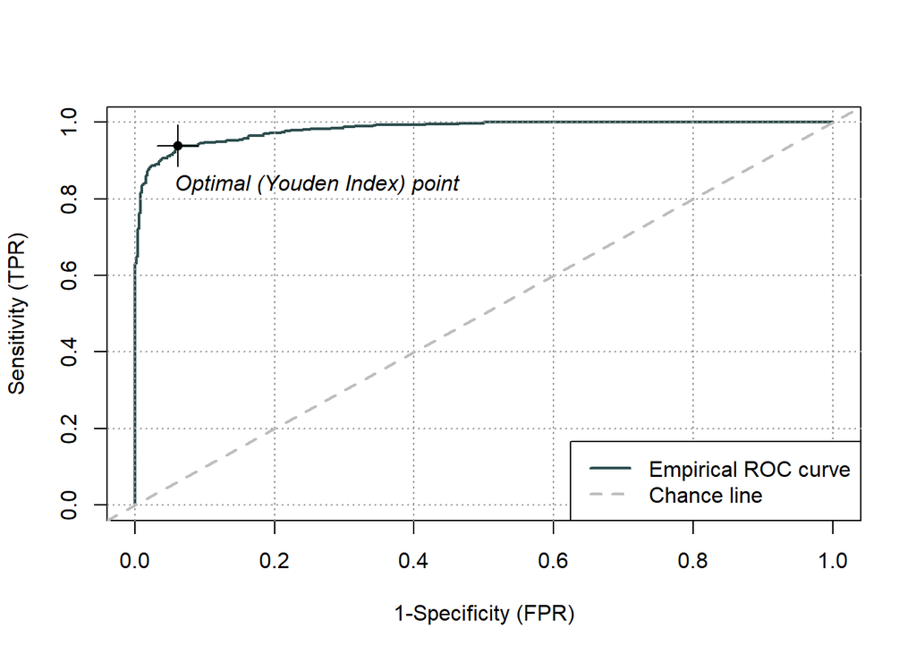

```r
xgb_test <- xgboost(data = data.matrix(sim[,-1]),
label = sim[,"y"],
eta = 0.5,
max_depth = 10,
nround=25,
subsample = 0.7,
colsample_bytree = 0.7,
objective = "binary:logistic",
verbose = 0
)
label  <- predict(xgb_test,xgb.DMatrix(data.matrix(sim_2[,-1])))
Roc <- rocit(score=label,class=sim_2$y )

plot(Roc,values=F)
```

```r
Cutoff <- which(Roc$FPR>=0.1) %>%
  min %>%
  Roc$Cutoff[.]

table(sim_2$y,label>Cutoff)
```

```
##
##     FALSE TRUE
##   0   471   52
##   1    25  452
```

```r
xgb.importance(model = xgb_test)
```

| Feature | Gain | Cover | Frequency |
| --- | --- | --- | --- |
| x5 | 0.51629671 | 0.26299181 | 0.19341564 |
| x1 | 0.14482848 | 0.13776418 | 0.10905350 |
| x6 | 0.09165595 | 0.11333810 | 0.09670782 |
| x10 | 0.04560136 | 0.10091138 | 0.09876543 |
| x7 | 0.03898047 | 0.06408870 | 0.08847737 |
| x9 | 0.03516680 | 0.08746392 | 0.08230453 |
| x4 | 0.03221431 | 0.05181687 | 0.06378601 |
| x8 | 0.03018108 | 0.05394460 | 0.09053498 |
| x3 | 0.02296459 | 0.04953263 | 0.07201646 |
| x2 | 0.02228912 | 0.04416324 | 0.04732510 |

[output cut: 1 more lines]

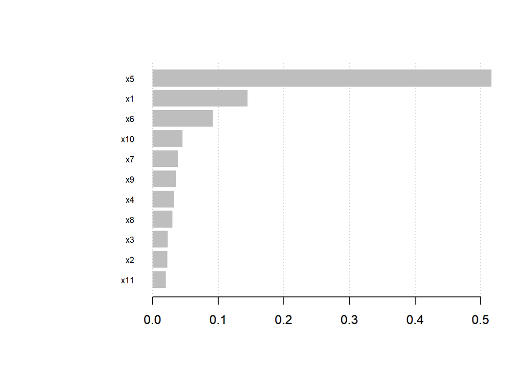

```r
xgb.importance(model = xgb_test) %>%
  xgb.plot.importance(top_n = 11)
```

### 第三次

```r
set.seed(123)
a <- matrix(sample(-2:2,25,replace = T),5,5)
sigmas <- t(a)%*%diag(1,5)%*%a
set.seed(12536)
x <- rmvnorm(n = 1000,mean = c(0,0,0,0,0),sigma = sigmas)
set.seed(1783)
x2 <- rmvnorm(n = 1000,mean = c(0,0,0,0,0),sigma = diag(1,5))
set.seed(519)
x_11 <- rnorm(n = 1000)
set.seed(53)
sd <- rnorm(1000,sd = 2)
y <- 10*x[,1]+5*x[,2]-3*x[,3]+4*x[,4]+8*x[,5]+10*x2[,1]+5*x2[,2]-3*x2[,3]+4*x2[,4]+8*x2[,5]+sd
sim <- data.frame(y,x,x2,x_11)


set.seed(17773)
x <- rmvnorm(n = 1000,mean = c(0,0,0,0,0),sigma = sigmas)
set.seed(18783)
x2 <- rmvnorm(n = 1000,mean = c(0,0,0,0,0),sigma = diag(1,5))
set.seed(5994)
x_11 <- rnorm(n = 1000)
set.seed(84)
sd <- rnorm(1000,sd = 2)
y <- 10*x[,1]+5*x[,2]-3*x[,3]+4*x[,4]+8*x[,5]+10*x2[,1]+5*x2[,2]-3*x2[,3]+4*x2[,4]+8*x2[,5]+sd
sim_2 <- data.frame(y,x,x2,x_11)
names(sim) <- c("y",paste0("x",1:11))
names(sim_2) <- c("y",paste0("x",1:11))
print("直接將生成的資料放進回歸中測試")
```

```
## [1] "直接將生成的資料放進回歸中測試"
```

```r
lm(y~.,data = sim) %>% summary()
```

```
##
## Call:
## lm(formula = y ~ ., data = sim)
##
## Residuals:
##     Min      1Q  Median      3Q     Max
## -6.6401 -1.4904  0.0891  1.3472  6.6518
##
## Coefficients:
##             Estimate Std. Error t value Pr(>|t|)
## (Intercept)  0.03353    0.06484   0.517   0.6052
## x1           9.93739    0.09120 108.957   <2e-16 ***
## x2           5.24430    0.14045  37.338   <2e-16 ***
## x3          -3.11660    0.06315 -49.349   <2e-16 ***
## x4           4.26123    0.11579  36.802   <2e-16 ***
## x5           7.81942    0.06952 112.470   <2e-16 ***
## x6           9.97606    0.06469 154.221   <2e-16 ***
## x7           4.91991    0.06431  76.500   <2e-16 ***
## x8          -3.07587    0.06415 -47.950   <2e-16 ***
## x9           3.98578    0.06200  64.290   <2e-16 ***
## x10          7.94645    0.06409 123.991   <2e-16 ***
## x11         -0.12066    0.06449  -1.871   0.0616 .
## ---
## Signif. codes:  0 '***' 0.001 '**' 0.01 '*' 0.05 '.' 0.1 ' ' 1
##
## Residual standard error: 2.041 on 988 degrees of freedom
## Multiple R-squared:  0.9972, Adjusted R-squared:  0.9972
## F-statistic: 3.179e+04 on 11 and 988 DF,  p-value: < 2.2e-16
```

```r
label  <- lm(y~.,data = sim) %>% predict(sim_2)
print("MSE")
```

```
## [1] "MSE"
```

```r
mean((sim_2$y-label)^2)
```

```
## [1] 3.990315
```

```r
print("xgboost")
```

```
## [1] "xgboost"
```

```r
xgb_test <- xgboost(data = data.matrix(sim[,-1]),
label = sim[,"y"],
eta = 0.5,
max_depth = 10,
nround=25,
subsample = 0.7,
colsample_bytree = 0.7,
objective = "reg:squarederror",
verbose = 0
)
label  <- predict(xgb_test,xgb.DMatrix(data.matrix(sim_2[,-1])))
print("MSE")
```

```
## [1] "MSE"
```

```r
mean((sim_2$y-label)^2)
```

```
## [1] 642.8206
```

```r
xgb.importance(model = xgb_test)
```

| Feature | Gain | Cover | Frequency |
| --- | --- | --- | --- |
| x4 | 0.20250002 | 0.08762671 | 0.09543120 |
| x1 | 0.12335072 | 0.08328744 | 0.13409029 |
| x6 | 0.09788276 | 0.09999092 | 0.08840227 |
| x10 | 0.09656519 | 0.06638424 | 0.06190862 |
| x2 | 0.08347386 | 0.09613581 | 0.11678832 |
| x9 | 0.08209950 | 0.09919206 | 0.08218437 |
| x7 | 0.07376073 | 0.08239175 | 0.07785888 |
| x3 | 0.07088118 | 0.13268375 | 0.11138145 |
| x11 | 0.06733354 | 0.05776016 | 0.07001892 |
| x8 | 0.05691380 | 0.07190970 | 0.06650446 |

[output cut: 1 more lines]

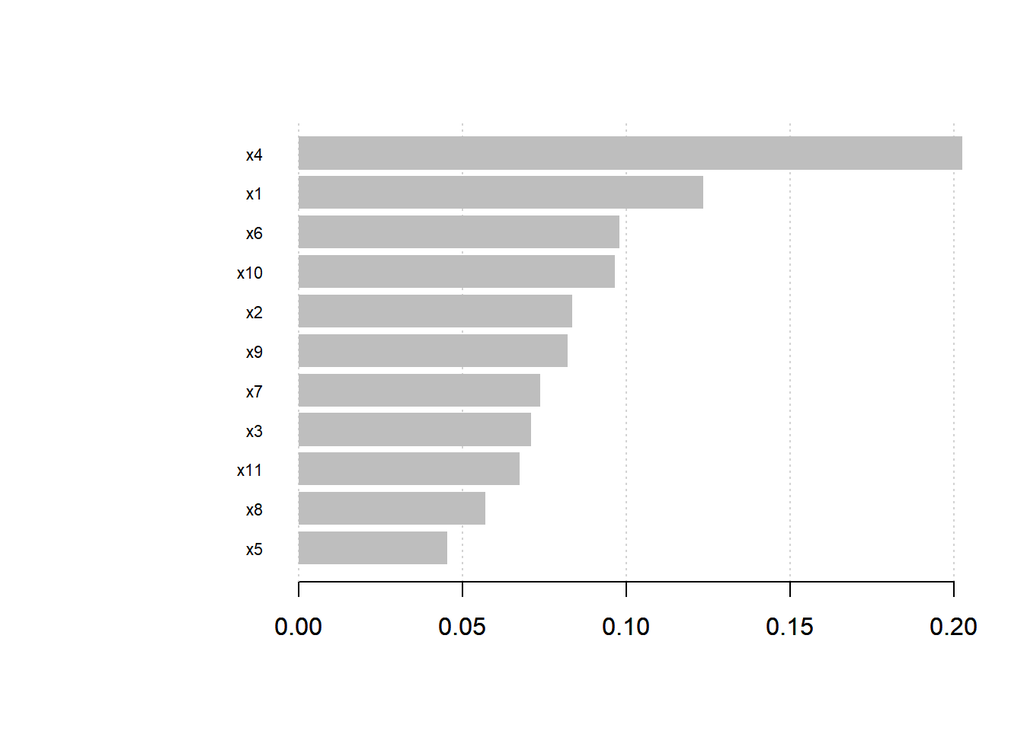

```r
xgb.importance(model = xgb_test) %>%
  xgb.plot.importance(top_n = 11)
```

```r
sim$y <- ifelse(sim$y>0,1,0)
sim_2$y <- ifelse(sim_2$y>0,1,0)
glm(y~.,family = binomial(),data = sim) %>% summary()
```

```
##
## Call:
## glm(formula = y ~ ., family = binomial(), data = sim)
##
## Deviance Residuals:
##    Min      1Q  Median      3Q     Max
## -1.581   0.000   0.000   0.000   3.312
##
## Coefficients:
##             Estimate Std. Error z value Pr(>|z|)
## (Intercept)   0.3195     0.3953   0.808 0.418956
## x1           12.8131     3.0107   4.256 2.08e-05 ***
## x2            6.3362     1.7540   3.612 0.000303 ***
## x3           -4.1159     1.0622  -3.875 0.000107 ***
## x4            4.9433     1.3803   3.581 0.000342 ***
## x5           10.3198     2.4014   4.297 1.73e-05 ***
## x6           12.7361     2.8760   4.428 9.49e-06 ***
## x7            6.2449     1.4935   4.181 2.90e-05 ***
## x8           -4.9432     1.1926  -4.145 3.40e-05 ***
## x9            5.9064     1.4302   4.130 3.63e-05 ***
## x10          11.1367     2.6057   4.274 1.92e-05 ***
## x11          -0.8381     0.4678  -1.791 0.073219 .
## ---
## Signif. codes:  0 '***' 0.001 '**' 0.01 '*' 0.05 '.' 0.1 ' ' 1
##
## (Dispersion parameter for binomial family taken to be 1)
##
##     Null deviance: 1386.150  on 999  degrees of freedom
## Residual deviance:   49.246  on 988  degrees of freedom
## AIC: 73.246
##
## Number of Fisher Scoring iterations: 13
```

```r
label  <- glm(y~.,family = binomial(),data = sim) %>% predict(sim_2,type="response")
```

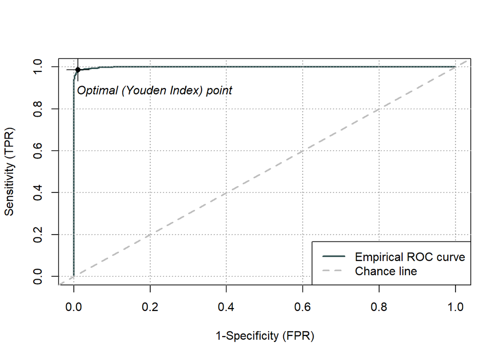

```r
Roc <- rocit(score=label,class=sim_2$y )

plot(Roc,values=F)
```

```r
Cutoff <- which(Roc$FPR>=0.01) %>%
  min %>%
  Roc$Cutoff[.]
table(sim_2$y,label>Cutoff)
```

```
##
##     FALSE TRUE
##   0   468    4
##   1    13  515
```

```r
print("xgboost")
```

```
## [1] "xgboost"
```

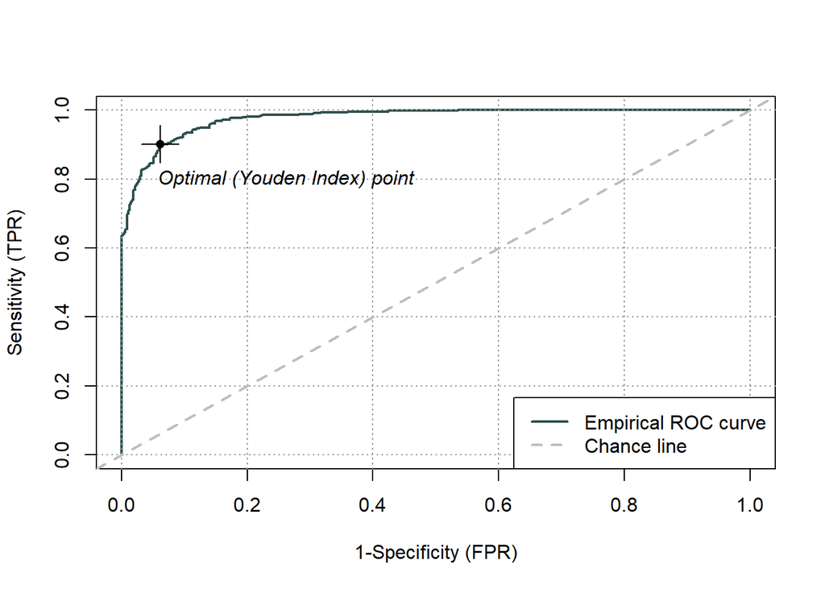

```r
xgb_test <- xgboost(data = data.matrix(sim[,-1]),
label = sim[,"y"],
eta = 0.5,
max_depth = 10,
nround=25,
subsample = 0.7,
colsample_bytree = 0.7,
objective = "binary:logistic",
verbose = 0
)
label  <- predict(xgb_test,xgb.DMatrix(data.matrix(sim_2[,-1])))
Roc <- rocit(score=label,class=sim_2$y )

plot(Roc,values=F)
```

```r
Cutoff <- which(Roc$FPR>=0.1) %>%
  min %>%
  Roc$Cutoff[.]

table(sim_2$y,label>Cutoff)
```

```
##
##     FALSE TRUE
##   0   425   47
##   1    36  492
```

```r
xgb.importance(model = xgb_test)
```

| Feature | Gain | Cover | Frequency |
| --- | --- | --- | --- |
| x5 | 0.51705743 | 0.28613365 | 0.18565401 |
| x1 | 0.19474768 | 0.20528324 | 0.16455696 |
| x6 | 0.05583944 | 0.10160436 | 0.09282700 |
| x10 | 0.05191407 | 0.08592562 | 0.09704641 |
| x7 | 0.03975034 | 0.06638720 | 0.09493671 |
| x9 | 0.03411843 | 0.06175292 | 0.07594937 |
| x8 | 0.02829484 | 0.04378795 | 0.06962025 |
| x3 | 0.02640528 | 0.05154430 | 0.04852321 |
| x11 | 0.02314041 | 0.04452439 | 0.07594937 |
| x2 | 0.01784751 | 0.03241069 | 0.05696203 |

[output cut: 1 more lines]

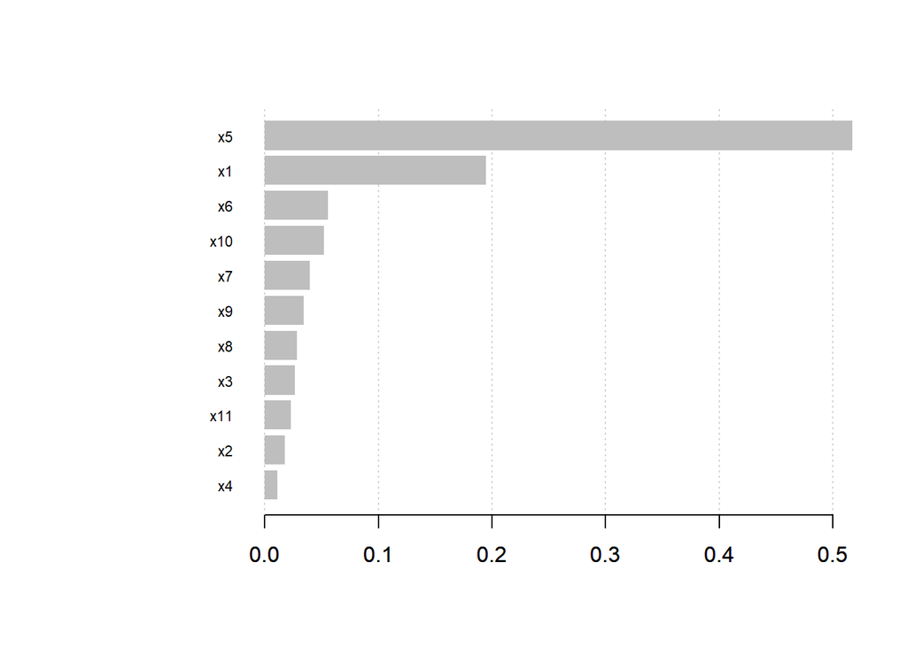

```r
xgb.importance(model = xgb_test) %>%
  xgb.plot.importance(top_n = 11)
```

## 資料二(一般項加交互作用項)

因為回歸沒有加上交互作用項，所以兩個的預測結果都很差。

$x_{1 \sim 10}\sim MN(\mu , \Sigma )$ $\mu=(0,0,0,0,0,0,0,0,0,0)$
$$\Sigma = \begin{pmatrix}
1 & 0 & 0 & 0 & 0 & 0 & 0 & 0 & 0 & 0\\
0 & 1& 0 & 0 & 0 & 0 & 0 & 0 & 0 & 0\\
0 & 0& 1 & 0 & 0 & 0 & 0 & 0 & 0 & 0\\
0 & 0& 0 & 1 & 0 & 0 & 0 & 0 & 0 & 0\\
0 & 0& 0 & 0 & 1 & 0 & 0 & 0 & 0 & 0\\
0 & 0& 0 & 0 & 0 & 1 & 0 & 0 & 0 & 0\\
0 & 0& 0 & 0 & 0 & 0 & 1 & 0 & 0 & 0\\
0 & 0& 0 & 0 & 0 & 0 & 0 & 1 & 0 & 0\\
0 & 0& 0 & 0 & 0 & 0 & 0 & 0 & 1 & 0\\
0 & 0& 0 & 0 & 0 & 0 & 0 & 0 & 0 & 1
\end{pmatrix}$$

$x_{11} \sim N(0,1)$

$y=10x_1+5x_2-3x_3+4x_4+8x_5-7x_6+9x_7-2x_8+5x_9-4x_{10}+10x_1x_2-7x_3x_4+\epsilon$

$\epsilon \sim N(0,4)$

### 第一次

```r
set.seed(1423)
x <- rmvnorm(n = 1000,mean = c(0,0,0,0,0,0,0,0,0,0),sigma = diag(1,10))
set.seed(597)
x_11 <- rnorm(n = 1000)
set.seed(55)
sd <- rnorm(1000,sd = 2)
y <- 10*x[,1]+5*x[,2]-3*x[,3]+4*x[,4]+8*x[,5]-7*x[,6]+9*x[,7]-2*x[,8]+5*x[,9]-4*x[,10]+10*x[,1]*x[,2]-7*x[,3]*x[,4]+sd
sim <- data.frame(y,x,x_11)


set.seed(1232)
x <- rmvnorm(n = 1000,mean = c(0,0,0,0,0,0,0,0,0,0),sigma = diag(1,10))
set.seed(599)
x_11 <- rnorm(n = 1000)
set.seed(57)
sd <- rnorm(1000,sd = 2)
y <- 10*x[,1]+5*x[,2]-3*x[,3]+4*x[,4]+8*x[,5]-7*x[,6]+9*x[,7]-2*x[,8]+5*x[,9]-4*x[,10]+10*x[,1]*x[,2]-7*x[,3]*x[,4]+sd
sim_2 <- data.frame(y,x,x_11)
names(sim) <- c("y",paste0("x",1:11))
names(sim_2) <- c("y",paste0("x",1:11))
print("直接將生成的資料放進回歸中測試")
```

```
## [1] "直接將生成的資料放進回歸中測試"
```

```r
lm(y~.,data = sim) %>% summary()
```

```
##
## Call:
## lm(formula = y ~ ., data = sim)
##
## Residuals:
##     Min      1Q  Median      3Q     Max
## -85.942  -5.793   0.192   6.298  44.739
##
## Coefficients:
##              Estimate Std. Error t value Pr(>|t|)
## (Intercept)  0.165030   0.400657   0.412  0.68050
## x1          10.557616   0.409828  25.761  < 2e-16 ***
## x2           4.915891   0.402556  12.212  < 2e-16 ***
## x3          -3.192580   0.405994  -7.864 9.74e-15 ***
## x4           3.603404   0.396337   9.092  < 2e-16 ***
## x5           7.693313   0.401413  19.166  < 2e-16 ***
## x6          -6.451068   0.411352 -15.683  < 2e-16 ***
## x7           9.688514   0.400851  24.170  < 2e-16 ***
## x8          -1.199748   0.399833  -3.001  0.00276 **
## x9           4.958909   0.406901  12.187  < 2e-16 ***
## x10         -3.785909   0.401048  -9.440  < 2e-16 ***
## x11         -0.001948   0.392907  -0.005  0.99604
## ---
## Signif. codes:  0 '***' 0.001 '**' 0.01 '*' 0.05 '.' 0.1 ' ' 1
##
## Residual standard error: 12.64 on 988 degrees of freedom
## Multiple R-squared:  0.7117, Adjusted R-squared:  0.7085
## F-statistic: 221.7 on 11 and 988 DF,  p-value: < 2.2e-16
```

```r
label  <- lm(y~.,data = sim) %>% predict(sim_2)
print("MSE")
```

```
## [1] "MSE"
```

```r
mean((sim_2$y-label)^2)
```

```
## [1] 154.7627
```

```r
print("xgboost")
```

```
## [1] "xgboost"
```

```r
xgb_test <- xgboost(data = data.matrix(sim[,-1]),
label = sim[,"y"],
eta = 0.5,
max_depth = 10,
nround=25,
subsample = 0.7,
colsample_bytree = 0.7,
objective = "reg:squarederror",
verbose = 0
)
label  <- predict(xgb_test,xgb.DMatrix(data.matrix(sim_2[,-1])))
print("MSE")
```

```
## [1] "MSE"
```

```r
mean((sim_2$y-label)^2)
```

```
## [1] 262.7634
```

```r
xgb.importance(model = xgb_test)
```

| Feature | Gain | Cover | Frequency |
| --- | --- | --- | --- |
| x2 | 0.19732856 | 0.13082898 | 0.13217391 |
| x7 | 0.14917105 | 0.10900595 | 0.08289855 |
| x5 | 0.14704673 | 0.07245418 | 0.06637681 |
| x3 | 0.09807424 | 0.08037990 | 0.11043478 |
| x1 | 0.08828350 | 0.11789052 | 0.16405797 |
| x6 | 0.07520714 | 0.12195655 | 0.09507246 |
| x10 | 0.06660281 | 0.05640854 | 0.06521739 |
| x9 | 0.05716084 | 0.08373589 | 0.06898551 |
| x8 | 0.05112941 | 0.05616580 | 0.06666667 |
| x11 | 0.04434556 | 0.07244811 | 0.07217391 |

[output cut: 1 more lines]

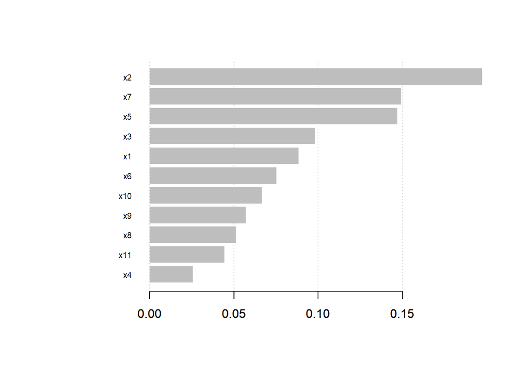

```r
xgb.importance(model = xgb_test) %>%
  xgb.plot.importance(top_n = 11)
```

```r
sim$y <- ifelse(sim$y>0,1,0)
sim_2$y <- ifelse(sim_2$y>0,1,0)
glm(y~.,family = binomial(),data = sim) %>% summary()
```

```
##
## Call:
## glm(formula = y ~ ., family = binomial(), data = sim)
##
## Deviance Residuals:
##     Min       1Q   Median       3Q      Max
## -2.6851  -0.5593  -0.0614   0.4783   3.2665
##
## Coefficients:
##             Estimate Std. Error z value Pr(>|z|)
## (Intercept) -0.19859    0.09542  -2.081 0.037412 *
## x1           1.54925    0.12848  12.058  < 2e-16 ***
## x2           0.76234    0.10440   7.302 2.83e-13 ***
## x3          -0.60777    0.10298  -5.902 3.59e-09 ***
## x4           0.52134    0.09577   5.443 5.23e-08 ***
## x5           1.31090    0.12137  10.801  < 2e-16 ***
## x6          -0.99105    0.11361  -8.724  < 2e-16 ***
## x7           1.67072    0.13597  12.288  < 2e-16 ***
## x8          -0.32304    0.09778  -3.304 0.000954 ***
## x9           0.89279    0.11035   8.090 5.95e-16 ***
## x10         -0.57533    0.09799  -5.871 4.33e-09 ***
## x11          0.10232    0.09396   1.089 0.276182
## ---
## Signif. codes:  0 '***' 0.001 '**' 0.01 '*' 0.05 '.' 0.1 ' ' 1
##
## (Dispersion parameter for binomial family taken to be 1)
##
##     Null deviance: 1383.59  on 999  degrees of freedom
## Residual deviance:  703.37  on 988  degrees of freedom
## AIC: 727.37
##
## Number of Fisher Scoring iterations: 6
```

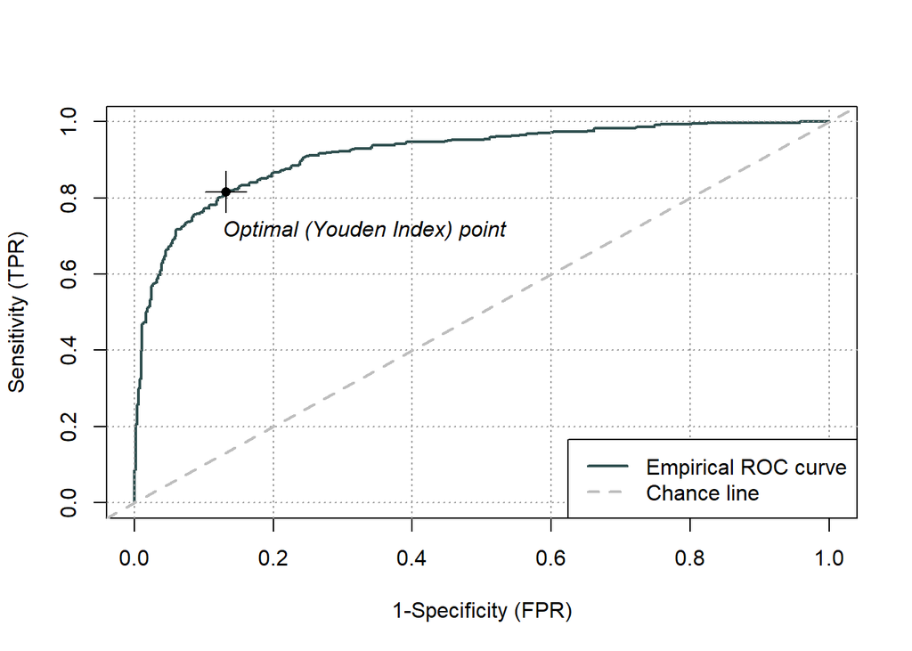

```r
label  <- glm(y~.,family = binomial(),data = sim) %>% predict(sim_2,type="response")
Roc <- rocit(score=label,class=sim_2$y )

plot(Roc,values=F)
```

```r
Cutoff <- which(Roc$FPR>=0.1) %>%
  min %>%
  Roc$Cutoff[.]
table(sim_2$y,label>Cutoff)
```

```
##
##     FALSE TRUE
##   0   479   53
##   1   106  362
```

```r
print("xgboost")
```

```
## [1] "xgboost"
```

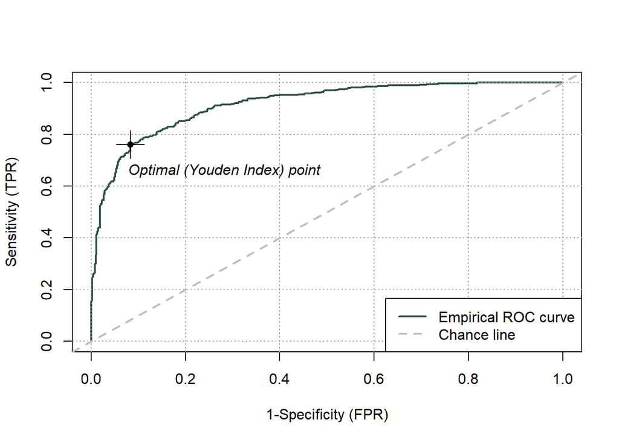

```r
xgb_test <- xgboost(data = data.matrix(sim[,-1]),
label = sim[,"y"],
eta = 0.5,
max_depth = 10,
nround=25,
subsample = 0.7,
colsample_bytree = 0.7,
objective = "binary:logistic",
verbose = 0
)
label  <- predict(xgb_test,xgb.DMatrix(data.matrix(sim_2[,-1])))
Roc <- rocit(score=label,class=sim_2$y )

plot(Roc,values=F)
```

```r
Cutoff <- which(Roc$FPR>=0.1) %>%
  min %>%
  Roc$Cutoff[.]

table(sim_2$y,label>Cutoff)
```

[output not shown]

```r
xgb.importance(model = xgb_test)
```

| Feature | Gain | Cover | Frequency |
| --- | --- | --- | --- |
| x1 | 0.12311287 | 0.11734637 | 0.09316770 |
| x3 | 0.12246213 | 0.09733678 | 0.12173913 |
| x6 | 0.11662786 | 0.10065680 | 0.10807453 |
| x5 | 0.11438397 | 0.10416279 | 0.06956522 |
| x7 | 0.10475225 | 0.10750234 | 0.06459627 |
| x2 | 0.10436105 | 0.10882965 | 0.10931677 |
| x10 | 0.09092932 | 0.09399514 | 0.10310559 |
| x8 | 0.07277257 | 0.07563900 | 0.10683230 |
| x4 | 0.06376109 | 0.06792441 | 0.08819876 |
| x9 | 0.06027541 | 0.08410758 | 0.06459627 |

[output cut: 1 more lines]

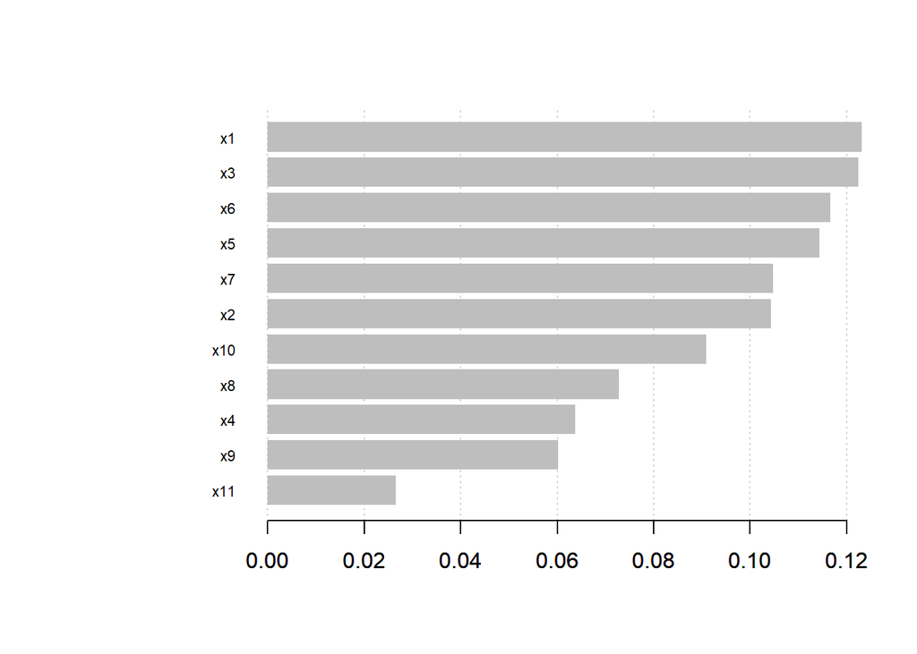

```r
xgb.importance(model = xgb_test) %>%
  xgb.plot.importance(top_n = 11)
```

### 第二次

```r
set.seed(17423)
x <- rmvnorm(n = 1000,mean = c(0,0,0,0,0,0,0,0,0,0),sigma = diag(1,10))
set.seed(5997)
x_11 <- rnorm(n = 1000)
set.seed(515)
sd <- rnorm(1000,sd = 2)
y <- 10*x[,1]+5*x[,2]-3*x[,3]+4*x[,4]+8*x[,5]-7*x[,6]+9*x[,7]-2*x[,8]+5*x[,9]-4*x[,10]+10*x[,1]*x[,2]-7*x[,3]*x[,4]+sd
sim <- data.frame(y,x,x_11)


set.seed(12632)
x <- rmvnorm(n = 1000,mean = c(0,0,0,0,0,0,0,0,0,0),sigma = diag(1,10))
set.seed(5998)
x_11 <- rnorm(n = 1000)
set.seed(597)
sd <- rnorm(1000,sd = 2)
y <- 10*x[,1]+5*x[,2]-3*x[,3]+4*x[,4]+8*x[,5]-7*x[,6]+9*x[,7]-2*x[,8]+5*x[,9]-4*x[,10]+10*x[,1]*x[,2]-7*x[,3]*x[,4]+sd
sim_2 <- data.frame(y,x,x_11)
names(sim) <- c("y",paste0("x",1:11))
names(sim_2) <- c("y",paste0("x",1:11))
print("直接將生成的資料放進回歸中測試")
```

```
## [1] "直接將生成的資料放進回歸中測試"
```

```r
lm(y~.,data = sim) %>% summary()
```

```
##
## Call:
## lm(formula = y ~ ., data = sim)
##
## Residuals:
##     Min      1Q  Median      3Q     Max
## -92.902  -6.056  -0.466   5.957  65.632
##
## Coefficients:
##             Estimate Std. Error t value Pr(>|t|)
## (Intercept)   0.4141     0.4196   0.987    0.324
## x1            9.5639     0.4217  22.680  < 2e-16 ***
## x2            3.8898     0.4198   9.265  < 2e-16 ***
## x3           -3.2399     0.4139  -7.828 1.27e-14 ***
## x4            4.2391     0.4124  10.279  < 2e-16 ***
## x5            7.8879     0.4060  19.430  < 2e-16 ***
## x6           -7.2764     0.4043 -17.998  < 2e-16 ***
## x7            9.3866     0.4233  22.174  < 2e-16 ***
## x8           -2.1807     0.4132  -5.277 1.61e-07 ***
## x9            5.6787     0.4400  12.905  < 2e-16 ***
## x10          -3.8891     0.4132  -9.411  < 2e-16 ***
## x11           0.3052     0.4148   0.736    0.462
## ---
## Signif. codes:  0 '***' 0.001 '**' 0.01 '*' 0.05 '.' 0.1 ' ' 1
##
## Residual standard error: 13.14 on 988 degrees of freedom
## Multiple R-squared:  0.7034, Adjusted R-squared:  0.7001
## F-statistic:   213 on 11 and 988 DF,  p-value: < 2.2e-16
```

```r
label  <- lm(y~.,data = sim) %>% predict(sim_2)
print("MSE")
```

```
## [1] "MSE"
```

```r
mean((sim_2$y-label)^2)
```

```
## [1] 160.6673
```

```r
print("xgboost")
```

```
## [1] "xgboost"
```

```r
xgb_test <- xgboost(data = data.matrix(sim[,-1]),
label = sim[,"y"],
eta = 0.5,
max_depth = 10,
nround=25,
subsample = 0.7,
colsample_bytree = 0.7,
objective = "reg:squarederror",
verbose = 0
)
label  <- predict(xgb_test,xgb.DMatrix(data.matrix(sim_2[,-1])))
print("MSE")
```

```
## [1] "MSE"
```

```r
mean((sim_2$y-label)^2)
```

```
## [1] 236.9217
```

```r
xgb.importance(model = xgb_test)
```

| Feature | Gain | Cover | Frequency |
| --- | --- | --- | --- |
| x1 | 0.18543520 | 0.13993646 | 0.19170840 |
| x5 | 0.14169645 | 0.10280909 | 0.09376739 |
| x6 | 0.12503676 | 0.07583398 | 0.07178631 |
| x7 | 0.12339887 | 0.10629684 | 0.07373400 |
| x2 | 0.11442605 | 0.13747310 | 0.16026711 |
| x4 | 0.08995393 | 0.09487022 | 0.08291597 |
| x10 | 0.06183200 | 0.06580977 | 0.04257095 |
| x9 | 0.06086680 | 0.07535838 | 0.06455203 |
| x3 | 0.04590627 | 0.10231520 | 0.11380078 |
| x11 | 0.03289641 | 0.05596849 | 0.06149137 |

[output cut: 1 more lines]

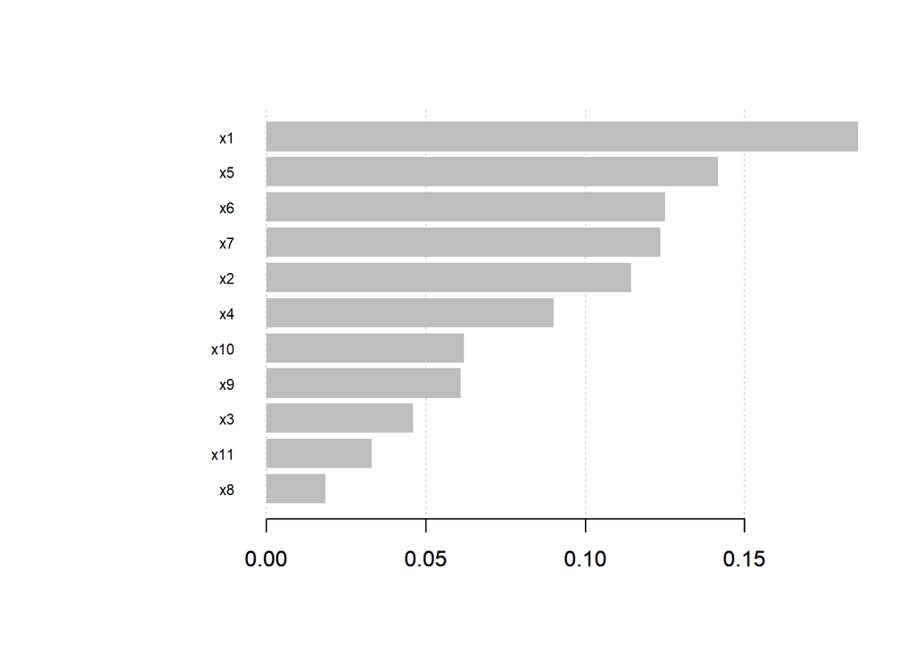

```r
xgb.importance(model = xgb_test) %>%
  xgb.plot.importance(top_n = 11)
```

```r
sim$y <- ifelse(sim$y>0,1,0)
sim_2$y <- ifelse(sim_2$y>0,1,0)
glm(y~.,family = binomial(),data = sim) %>% summary()
```

```
##
## Call:
## glm(formula = y ~ ., family = binomial(), data = sim)
##
## Deviance Residuals:
##     Min       1Q   Median       3Q      Max
## -2.8530  -0.5308  -0.0494   0.5654   2.8112
##
## Coefficients:
##              Estimate Std. Error z value Pr(>|z|)
## (Intercept) -0.009273   0.093659  -0.099  0.92113
## x1           1.118673   0.114603   9.761  < 2e-16 ***
## x2           0.485305   0.099863   4.860 1.18e-06 ***
## x3          -0.418858   0.093050  -4.501 6.75e-06 ***
## x4           0.670726   0.101379   6.616 3.69e-11 ***
## x5           1.198846   0.112834  10.625  < 2e-16 ***
## x6          -1.080510   0.105217 -10.269  < 2e-16 ***
## x7           1.409217   0.121016  11.645  < 2e-16 ***
## x8          -0.264115   0.093490  -2.825  0.00473 **
## x9           0.745512   0.106290   7.014 2.32e-12 ***
## x10         -0.772670   0.100683  -7.674 1.66e-14 ***
## x11          0.035526   0.090723   0.392  0.69537
## ---
## Signif. codes:  0 '***' 0.001 '**' 0.01 '*' 0.05 '.' 0.1 ' ' 1
##
## (Dispersion parameter for binomial family taken to be 1)
##
##     Null deviance: 1386.15  on 999  degrees of freedom
## Residual deviance:  731.48  on 988  degrees of freedom
## AIC: 755.48
##
## Number of Fisher Scoring iterations: 6
```

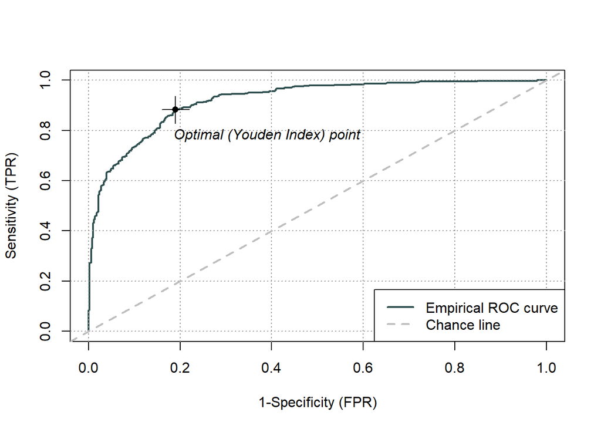

```r
label  <- glm(y~.,family = binomial(),data = sim) %>% predict(sim_2,type="response")
Roc <- rocit(score=label,class=sim_2$y )

plot(Roc,values=F)
```

```r
Cutoff <- which(Roc$FPR>=0.2) %>%
  min %>%
  Roc$Cutoff[.]
table(sim_2$y,label>Cutoff)
```

```
##
##     FALSE TRUE
##   0   405  101
##   1    56  438
```

```r
print("xgboost")
```

```
## [1] "xgboost"
```

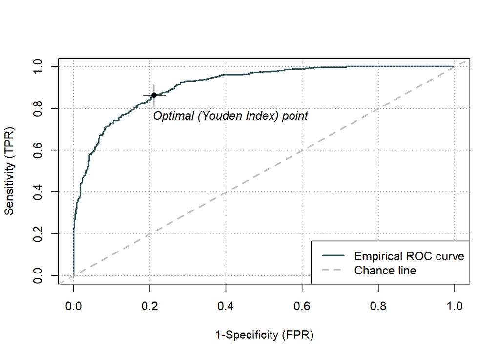

```r
xgb_test <- xgboost(data = data.matrix(sim[,-1]),
label = sim[,"y"],
eta = 0.5,
max_depth = 10,
nround=25,
subsample = 0.7,
colsample_bytree = 0.7,
objective = "binary:logistic",
verbose = 0
)
label  <- predict(xgb_test,xgb.DMatrix(data.matrix(sim_2[,-1])))
Roc <- rocit(score=label,class=sim_2$y )

plot(Roc,values=F)
```

```r
Cutoff <- which(Roc$FPR>=0.2) %>%
  min %>%
  Roc$Cutoff[.]

table(sim_2$y,label>Cutoff)
```

```
##
##     FALSE TRUE
##   0   405  101
##   1    78  416
```

```r
xgb.importance(model = xgb_test)
```

| Feature | Gain | Cover | Frequency |
| --- | --- | --- | --- |
| x7 | 0.16507619 | 0.11373944 | 0.09499358 |
| x5 | 0.14866071 | 0.14688872 | 0.13222080 |
| x6 | 0.12251316 | 0.12818873 | 0.10141207 |
| x1 | 0.11364133 | 0.11547907 | 0.10911425 |
| x3 | 0.08498616 | 0.08350471 | 0.10269576 |
| x4 | 0.08054306 | 0.07828698 | 0.09114249 |
| x2 | 0.07786996 | 0.08140970 | 0.09627728 |
| x10 | 0.07608513 | 0.08319286 | 0.07830552 |
| x9 | 0.04848647 | 0.06846513 | 0.05391528 |
| x11 | 0.04369461 | 0.04617203 | 0.06675225 |

[output cut: 1 more lines]

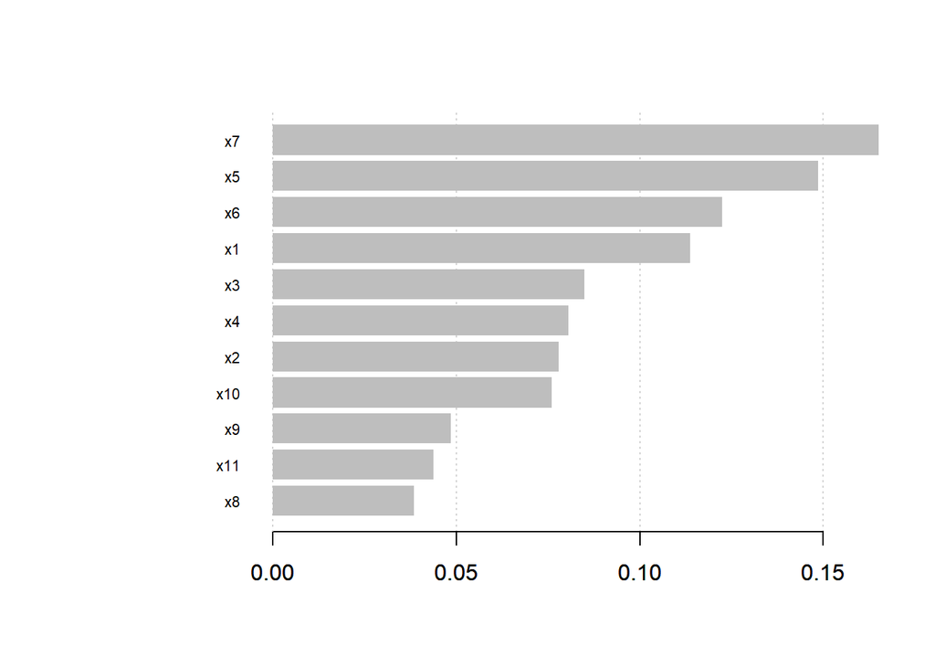

```r
xgb.importance(model = xgb_test) %>%
  xgb.plot.importance(top_n = 11)
```

### 第三次

```r
set.seed(1443)
x <- rmvnorm(n = 1000,mean = c(0,0,0,0,0,0,0,0,0,0),sigma = diag(1,10))
set.seed(5697)
x_11 <- rnorm(n = 1000)
set.seed(505)
sd <- rnorm(1000,sd = 2)
y <- 10*x[,1]+5*x[,2]-3*x[,3]+4*x[,4]+8*x[,5]-7*x[,6]+9*x[,7]-2*x[,8]+5*x[,9]-4*x[,10]+10*x[,1]*x[,2]-7*x[,3]*x[,4]+sd
sim <- data.frame(y,x,x_11)


set.seed(13232)
x <- rmvnorm(n = 1000,mean = c(0,0,0,0,0,0,0,0,0,0),sigma = diag(1,10))
set.seed(509)
x_11 <- rnorm(n = 1000)
set.seed(547)
sd <- rnorm(1000,sd = 2)
y <- 10*x[,1]+5*x[,2]-3*x[,3]+4*x[,4]+8*x[,5]-7*x[,6]+9*x[,7]-2*x[,8]+5*x[,9]-4*x[,10]+10*x[,1]*x[,2]-7*x[,3]*x[,4]+sd
sim_2 <- data.frame(y,x,x_11)
names(sim) <- c("y",paste0("x",1:11))
names(sim_2) <- c("y",paste0("x",1:11))
print("直接將生成的資料放進回歸中測試")
```

```
## [1] "直接將生成的資料放進回歸中測試"
```

```r
lm(y~.,data = sim) %>% summary()
```

```
##
## Call:
## lm(formula = y ~ ., data = sim)
##
## Residuals:
##     Min      1Q  Median      3Q     Max
## -55.206  -6.080   0.350   6.137  60.212
##
## Coefficients:
##             Estimate Std. Error t value Pr(>|t|)
## (Intercept) -0.07036    0.40114  -0.175    0.861
## x1          10.44107    0.40548  25.750  < 2e-16 ***
## x2           4.82926    0.40783  11.842  < 2e-16 ***
## x3          -3.25000    0.39671  -8.192 7.88e-16 ***
## x4           4.41255    0.40088  11.007  < 2e-16 ***
## x5           6.61688    0.41008  16.136  < 2e-16 ***
## x6          -6.63397    0.39905 -16.624  < 2e-16 ***
## x7           9.10882    0.39350  23.148  < 2e-16 ***
## x8          -1.79267    0.38818  -4.618 4.38e-06 ***
## x9           5.06657    0.39143  12.944  < 2e-16 ***
## x10         -5.30997    0.39938 -13.295  < 2e-16 ***
## x11         -0.24216    0.40644  -0.596    0.551
## ---
## Signif. codes:  0 '***' 0.001 '**' 0.01 '*' 0.05 '.' 0.1 ' ' 1
##
## Residual standard error: 12.65 on 988 degrees of freedom
## Multiple R-squared:  0.7147, Adjusted R-squared:  0.7115
## F-statistic:   225 on 11 and 988 DF,  p-value: < 2.2e-16
```

```r
label  <- lm(y~.,data = sim) %>% predict(sim_2)
print("MSE")
```

```
## [1] "MSE"
```

```r
mean((sim_2$y-label)^2)
```

```
## [1] 157.2393
```

```r
print("xgboost")
```

```
## [1] "xgboost"
```

```r
xgb_test <- xgboost(data = data.matrix(sim[,-1]),
label = sim[,"y"],
eta = 0.5,
max_depth = 10,
nround=25,
subsample = 0.7,
colsample_bytree = 0.7,
objective = "reg:squarederror",
verbose = 0
)
label  <- predict(xgb_test,xgb.DMatrix(data.matrix(sim_2[,-1])))
print("MSE")
```

```
## [1] "MSE"
```

```r
mean((sim_2$y-label)^2)
```

```
## [1] 209.2241
```

```r
xgb.importance(model = xgb_test)
```

| Feature | Gain | Cover | Frequency |
| --- | --- | --- | --- |
| x7 | 0.17502179 | 0.09018768 | 0.08354430 |
| x1 | 0.14169455 | 0.15460310 | 0.18322785 |
| x2 | 0.13501212 | 0.14436723 | 0.14873418 |
| x6 | 0.12382824 | 0.06515786 | 0.06297468 |
| x5 | 0.10757075 | 0.09758769 | 0.09367089 |
| x10 | 0.08006530 | 0.08551398 | 0.06329114 |
| x9 | 0.07439186 | 0.07953799 | 0.06360759 |
| x3 | 0.07312747 | 0.07396972 | 0.08386076 |
| x8 | 0.04824680 | 0.06565079 | 0.06993671 |
| x4 | 0.02691685 | 0.09259147 | 0.09398734 |

[output cut: 1 more lines]

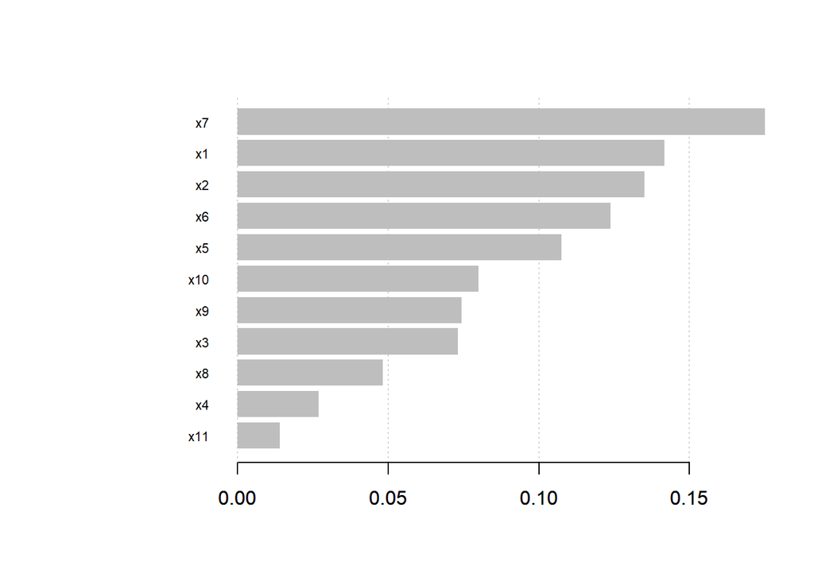

```r
xgb.importance(model = xgb_test) %>%
  xgb.plot.importance(top_n = 11)
```

```r
sim$y <- ifelse(sim$y>0,1,0)
sim_2$y <- ifelse(sim_2$y>0,1,0)
glm(y~.,family = binomial(),data = sim) %>% summary()
```

```
##
## Call:
## glm(formula = y ~ ., family = binomial(), data = sim)
##
## Deviance Residuals:
##     Min       1Q   Median       3Q      Max
## -2.7797  -0.4626  -0.0629   0.4787   3.6886
##
## Coefficients:
##             Estimate Std. Error z value Pr(>|z|)
## (Intercept) -0.28765    0.09781  -2.941  0.00327 **
## x1           1.55226    0.13147  11.807  < 2e-16 ***
## x2           0.69358    0.10770   6.440 1.19e-10 ***
## x3          -0.59968    0.10100  -5.938 2.89e-09 ***
## x4           0.70837    0.10416   6.801 1.04e-11 ***
## x5           1.10208    0.11921   9.245  < 2e-16 ***
## x6          -1.22921    0.12098 -10.160  < 2e-16 ***
## x7           1.46262    0.12280  11.910  < 2e-16 ***
## x8          -0.18236    0.09165  -1.990  0.04663 *
## x9           0.87218    0.10649   8.190 2.61e-16 ***
## x10         -0.88671    0.10888  -8.144 3.83e-16 ***
## x11         -0.13397    0.09845  -1.361  0.17360
## ---
## Signif. codes:  0 '***' 0.001 '**' 0.01 '*' 0.05 '.' 0.1 ' ' 1
##
## (Dispersion parameter for binomial family taken to be 1)
##
##     Null deviance: 1382.4  on 999  degrees of freedom
## Residual deviance:  683.3  on 988  degrees of freedom
## AIC: 707.3
##
## Number of Fisher Scoring iterations: 6
```

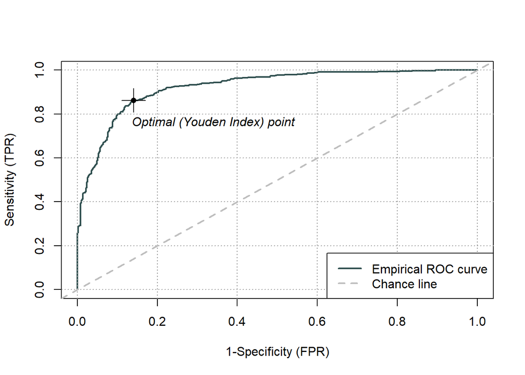

```r
label  <- glm(y~.,family = binomial(),data = sim) %>% predict(sim_2,type="response")
Roc <- rocit(score=label,class=sim_2$y )

plot(Roc,values=F)
```

```r
Cutoff <- which(Roc$FPR>=0.15) %>%
  min %>%
  Roc$Cutoff[.]
table(sim_2$y,label>Cutoff)
```

```
##
##     FALSE TRUE
##   0   437   76
##   1    67  420
```

```r
print("xgboost")
```

```
## [1] "xgboost"
```

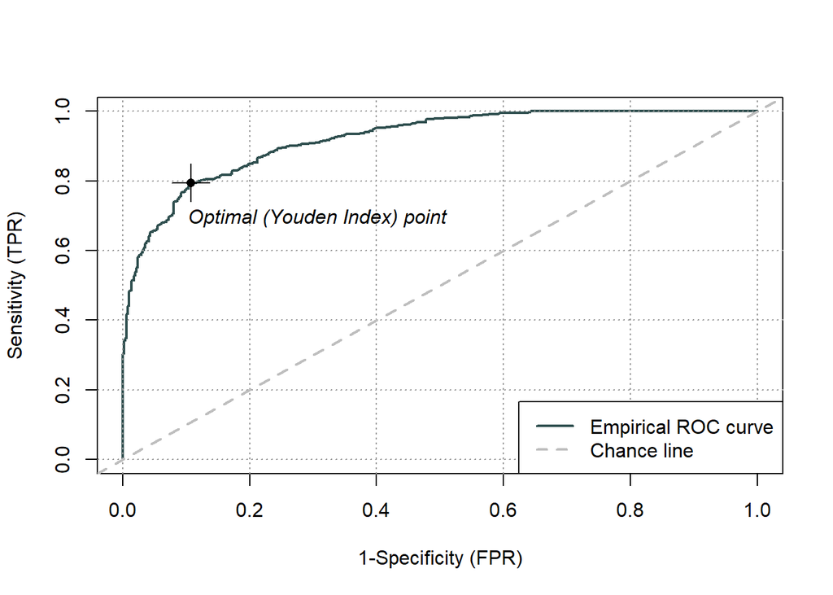

```r
xgb_test <- xgboost(data = data.matrix(sim[,-1]),
label = sim[,"y"],
eta = 0.5,
max_depth = 10,
nround=25,
subsample = 0.7,
colsample_bytree = 0.7,
objective = "binary:logistic",
verbose = 0
)
label  <- predict(xgb_test,xgb.DMatrix(data.matrix(sim_2[,-1])))
Roc <- rocit(score=label,class=sim_2$y )

plot(Roc,values=F)
```

```r
Cutoff <- which(Roc$FPR>=0.1) %>%
  min %>%
  Roc$Cutoff[.]

table(sim_2$y,label>Cutoff)
```

```
##
##     FALSE TRUE
##   0   462   51
##   1   108  379
```

```r
xgb.importance(model = xgb_test)
```

| Feature | Gain | Cover | Frequency |
| --- | --- | --- | --- |
| x7 | 0.16189051 | 0.13496612 | 0.11038108 |
| x1 | 0.13329396 | 0.13519642 | 0.09724047 |
| x5 | 0.11766153 | 0.10300467 | 0.11038108 |
| x6 | 0.11419483 | 0.11154140 | 0.08409987 |
| x9 | 0.10727506 | 0.10230875 | 0.10775296 |
| x4 | 0.09342532 | 0.08926712 | 0.10249671 |
| x3 | 0.07070984 | 0.07286802 | 0.10643890 |
| x10 | 0.06933786 | 0.09671936 | 0.07884363 |
| x2 | 0.04881392 | 0.07625841 | 0.06964520 |
| x11 | 0.04513932 | 0.03443800 | 0.06438896 |

[output cut: 1 more lines]

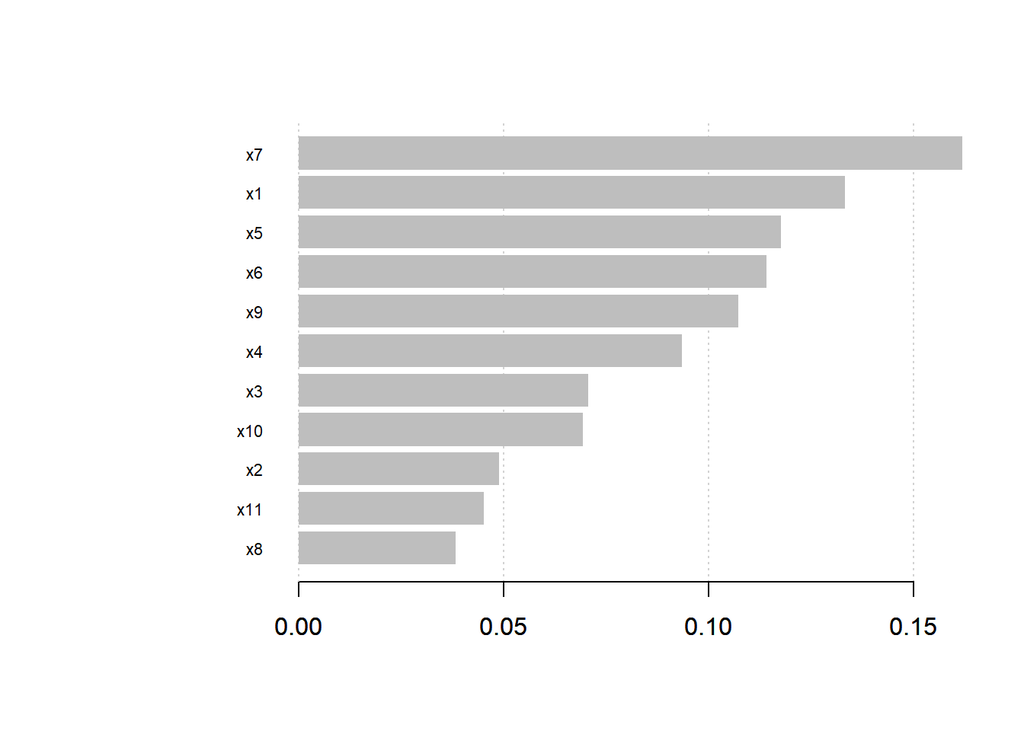

```r
xgb.importance(model = xgb_test) %>%
  xgb.plot.importance(top_n = 11)
```

## 資料三(只有交互作用項)

回歸表現得比XGboost還差，XGboost有大概抓到是那些變數。

$x_{1 \sim 10}\sim MN(\mu , \Sigma )$ $\mu=(0,0,0,0,0,0,0,0,0,0)$
$$\Sigma = \begin{pmatrix}
1 & 0 & 0 & 0 & 0 & 0 & 0 & 0 & 0 & 0\\
0 & 1& 0 & 0 & 0 & 0 & 0 & 0 & 0 & 0\\
0 & 0& 1 & 0 & 0 & 0 & 0 & 0 & 0 & 0\\
0 & 0& 0 & 1 & 0 & 0 & 0 & 0 & 0 & 0\\
0 & 0& 0 & 0 & 1 & 0 & 0 & 0 & 0 & 0\\
0 & 0& 0 & 0 & 0 & 1 & 0 & 0 & 0 & 0\\
0 & 0& 0 & 0 & 0 & 0 & 1 & 0 & 0 & 0\\
0 & 0& 0 & 0 & 0 & 0 & 0 & 1 & 0 & 0\\
0 & 0& 0 & 0 & 0 & 0 & 0 & 0 & 1 & 0\\
0 & 0& 0 & 0 & 0 & 0 & 0 & 0 & 0 & 1
\end{pmatrix}$$

$x_{11} \sim N(0,1)$

$y=+10x_1x_2-7x_3x_4-8x_6x_9+\epsilon$

$\epsilon \sim N(0,4)$

### 第一次

```r
set.seed(1423)
x <- rmvnorm(n = 1000,mean = c(0,0,0,0,0,0,0,0,0,0),sigma = diag(1,10))
set.seed(597)
x_11 <- rnorm(n = 1000)
set.seed(55)
sd <- rnorm(1000,sd = 2)
y <- 10*x[,1]*x[,2]-7*x[,3]*x[,4]-8*x[,6]*x[,9]+sd
sim <- data.frame(y,x,x_11)


set.seed(1232)
x <- rmvnorm(n = 1000,mean = c(0,0,0,0,0,0,0,0,0,0),sigma = diag(1,10))
set.seed(599)
x_11 <- rnorm(n = 1000)
set.seed(57)
sd <- rnorm(1000,sd = 2)
y <- 10*x[,1]*x[,2]-7*x[,3]*x[,4]-8*x[,6]*x[,9]+sd
sim_2 <- data.frame(y,x,x_11)
names(sim) <- c("y",paste0("x",1:11))
names(sim_2) <- c("y",paste0("x",1:11))
print("直接將生成的資料放進回歸中測試")
```

```
## [1] "直接將生成的資料放進回歸中測試"
```

```r
lm(y~.,data = sim) %>% summary()
```

```
##
## Call:
## lm(formula = y ~ ., data = sim)
##
## Residuals:
##     Min      1Q  Median      3Q     Max
## -83.817  -7.742  -0.181   7.901  54.558
##
## Coefficients:
##             Estimate Std. Error t value Pr(>|t|)
## (Intercept)  0.07275    0.46093   0.158   0.8746
## x1           0.24621    0.47148   0.522   0.6017
## x2          -0.45307    0.46312  -0.978   0.3282
## x3          -0.35031    0.46707  -0.750   0.4534
## x4          -0.62461    0.45596  -1.370   0.1710
## x5          -0.44605    0.46180  -0.966   0.3343
## x6           0.72032    0.47324   1.522   0.1283
## x7           0.91412    0.46116   1.982   0.0477 *
## x8           0.87039    0.45999   1.892   0.0588 .
## x9           0.57163    0.46812   1.221   0.2223
## x10          0.10677    0.46138   0.231   0.8170
## x11         -0.15419    0.45202  -0.341   0.7331
## ---
## Signif. codes:  0 '***' 0.001 '**' 0.01 '*' 0.05 '.' 0.1 ' ' 1
##
## Residual standard error: 14.54 on 988 degrees of freedom
## Multiple R-squared:  0.01598,    Adjusted R-squared:  0.005024
## F-statistic: 1.459 on 11 and 988 DF,  p-value: 0.1416
```

```r
label  <- lm(y~.,data = sim) %>% predict(sim_2)
print("MSE")
```

```
## [1] "MSE"
```

```r
mean((sim_2$y-label)^2)
```

```
## [1] 219.4285
```

```r
print("xgboost")
```

```
## [1] "xgboost"
```

```r
xgb_test <- xgboost(data = data.matrix(sim[,-1]),
label = sim[,"y"],
eta = 0.5,
max_depth = 10,
nround=25,
subsample = 0.7,
colsample_bytree = 0.7,
objective = "reg:squarederror",
verbose = 0
)
label  <- predict(xgb_test,xgb.DMatrix(data.matrix(sim_2[,-1])))
print("MSE")
```

```
## [1] "MSE"
```

```r
mean((sim_2$y-label)^2)
```

```
## [1] 155.2435
```

```r
xgb.importance(model = xgb_test)
```

| Feature | Gain | Cover | Frequency |
| --- | --- | --- | --- |
| x2 | 0.27540466 | 0.14149180 | 0.11853211 |
| x3 | 0.11660853 | 0.06647052 | 0.09614679 |
| x9 | 0.10260147 | 0.10955982 | 0.07119266 |
| x6 | 0.08954879 | 0.10014022 | 0.08770642 |
| x1 | 0.08452829 | 0.10943998 | 0.15963303 |
| x4 | 0.06682145 | 0.11037475 | 0.09614679 |
| x7 | 0.06282365 | 0.06734537 | 0.08807339 |
| x8 | 0.05386848 | 0.05886653 | 0.06422018 |
| x5 | 0.05232438 | 0.05248493 | 0.06422018 |
| x11 | 0.05073584 | 0.10217154 | 0.08366972 |

[output cut: 1 more lines]

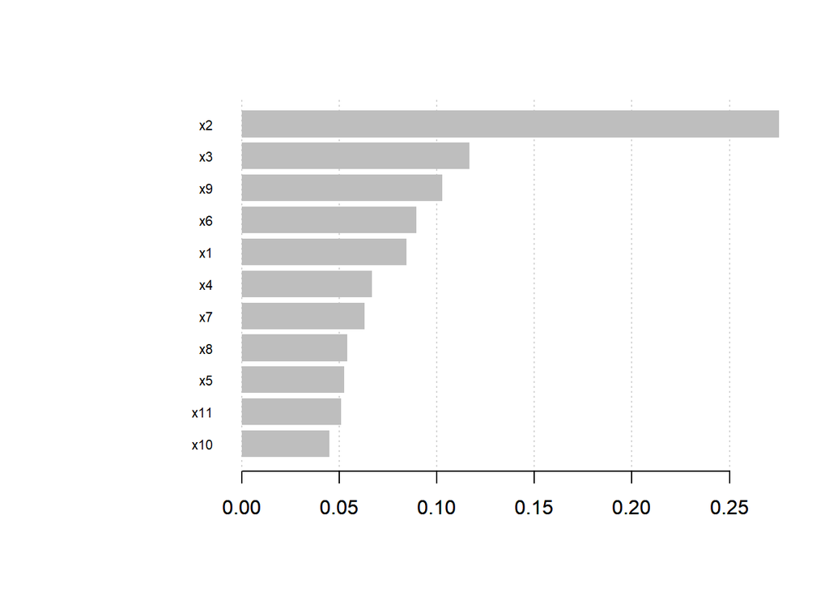

```r
xgb.importance(model = xgb_test) %>%
  xgb.plot.importance(top_n = 11)
```

```r
sim$y <- ifelse(sim$y>0,1,0)
sim_2$y <- ifelse(sim_2$y>0,1,0)
glm(y~.,family = binomial(),data = sim) %>% summary()
```

```
##
## Call:
## glm(formula = y ~ ., family = binomial(), data = sim)
##
## Deviance Residuals:
##     Min       1Q   Median       3Q      Max
## -1.5055  -1.1601  -0.9179   1.1729   1.5422
##
## Coefficients:
##              Estimate Std. Error z value Pr(>|z|)
## (Intercept) -0.007860   0.063895  -0.123   0.9021
## x1           0.104195   0.065528   1.590   0.1118
## x2          -0.013955   0.064192  -0.217   0.8279
## x3          -0.115564   0.065032  -1.777   0.0756 .
## x4          -0.102454   0.063332  -1.618   0.1057
## x5          -0.029891   0.064073  -0.467   0.6408
## x6           0.042205   0.065618   0.643   0.5201
## x7           0.058290   0.063993   0.911   0.3624
## x8           0.117733   0.063953   1.841   0.0656 .
## x9           0.102238   0.065077   1.571   0.1162
## x10          0.045602   0.063978   0.713   0.4760
## x11         -0.006867   0.062647  -0.110   0.9127
## ---
## Signif. codes:  0 '***' 0.001 '**' 0.01 '*' 0.05 '.' 0.1 ' ' 1
##
## (Dispersion parameter for binomial family taken to be 1)
##
##     Null deviance: 1386.3  on 999  degrees of freedom
## Residual deviance: 1370.3  on 988  degrees of freedom
## AIC: 1394.3
##
## Number of Fisher Scoring iterations: 4
```

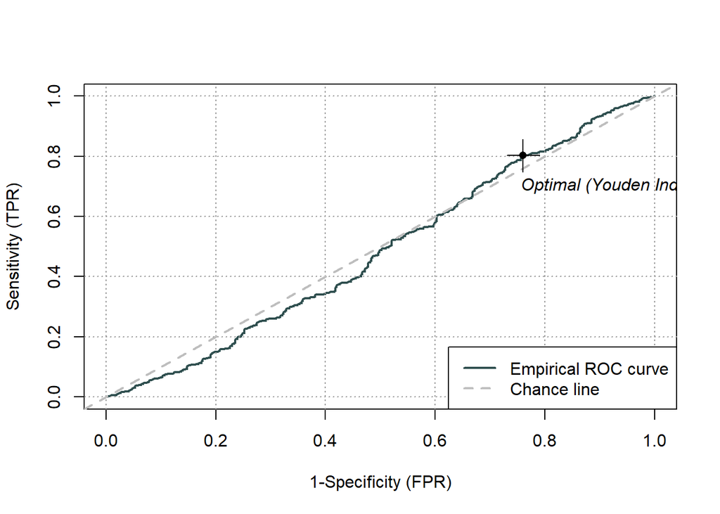

```r
label  <- glm(y~.,family = binomial(),data = sim) %>% predict(sim_2,type="response")
Roc <- rocit(score=label,class=sim_2$y )

plot(Roc,values=F)
```

```r
Cutoff <- which(Roc$FPR>=0.7) %>%
  min %>%
  Roc$Cutoff[.]
table(sim_2$y,label>Cutoff)
```

```
##
##     FALSE TRUE
##   0   147  341
##   1   145  367
```

```r
print("xgboost")
```

```
## [1] "xgboost"
```

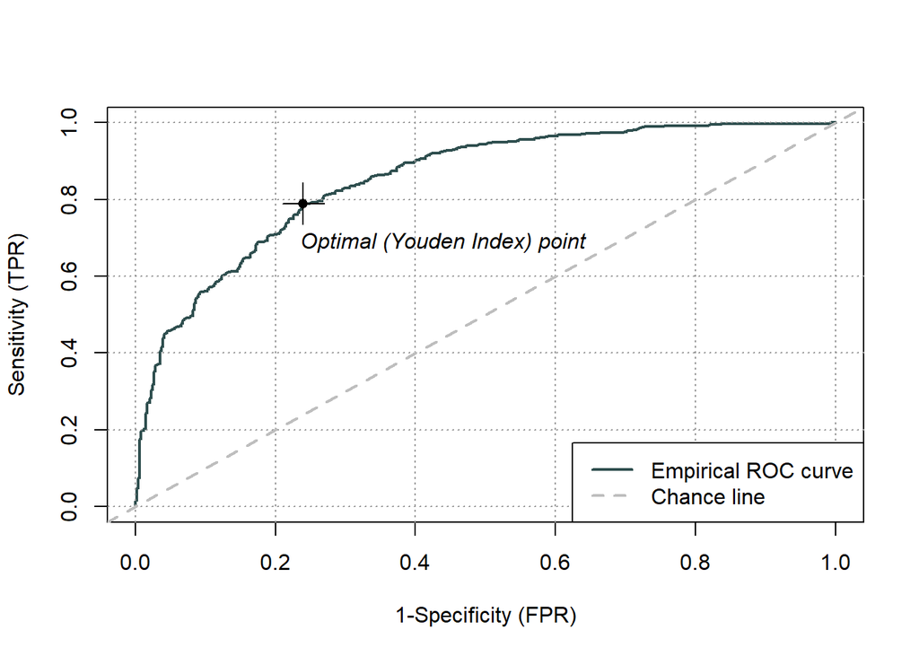

```r
xgb_test <- xgboost(data = data.matrix(sim[,-1]),
label = sim[,"y"],
eta = 0.5,
max_depth = 10,
nround=25,
subsample = 0.7,
colsample_bytree = 0.7,
objective = "binary:logistic",
verbose = 0
)
label  <- predict(xgb_test,xgb.DMatrix(data.matrix(sim_2[,-1])))
Roc <- rocit(score=label,class=sim_2$y )

plot(Roc,values=F)
```

```r
Cutoff <- which(Roc$FPR>=0.22) %>%
  min %>%
  Roc$Cutoff[.]

table(sim_2$y,label>Cutoff)
```

```
##
##     FALSE TRUE
##   0   381  107
##   1   128  384
```

```r
xgb.importance(model = xgb_test)
```

| Feature | Gain | Cover | Frequency |
| --- | --- | --- | --- |
| x3 | 0.15156648 | 0.14747216 | 0.13650465 |
| x6 | 0.14231891 | 0.13445976 | 0.11995863 |
| x2 | 0.12599722 | 0.08756177 | 0.09617373 |
| x4 | 0.11445944 | 0.11352282 | 0.10237849 |
| x1 | 0.10785881 | 0.11582083 | 0.09617373 |
| x9 | 0.09837677 | 0.10213273 | 0.09307135 |
| x10 | 0.07717881 | 0.07407381 | 0.10444674 |
| x5 | 0.06316404 | 0.05433817 | 0.05997932 |
| x8 | 0.05211673 | 0.08146384 | 0.08686660 |
| x11 | 0.03766036 | 0.05398359 | 0.05687694 |

[output cut: 1 more lines]

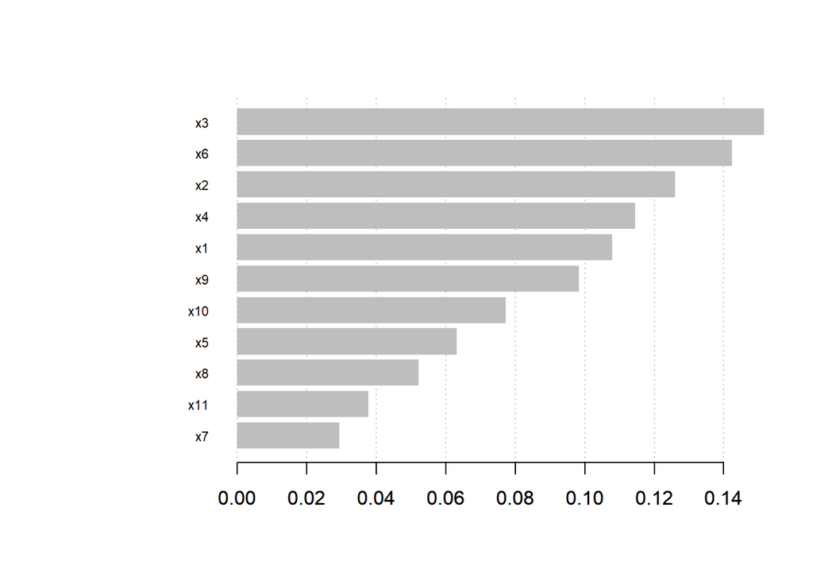

```r
xgb.importance(model = xgb_test) %>%
  xgb.plot.importance(top_n = 11)
```

### 第二次

```r
set.seed(17423)
x <- rmvnorm(n = 1000,mean = c(0,0,0,0,0,0,0,0,0,0),sigma = diag(1,10))
set.seed(5997)
x_11 <- rnorm(n = 1000)
set.seed(515)
sd <- rnorm(1000,sd = 2)
y <- 10*x[,1]*x[,2]-7*x[,3]*x[,4]-8*x[,6]*x[,9]+sd
sim <- data.frame(y,x,x_11)


set.seed(12632)
x <- rmvnorm(n = 1000,mean = c(0,0,0,0,0,0,0,0,0,0),sigma = diag(1,10))
set.seed(5998)
x_11 <- rnorm(n = 1000)
set.seed(597)
sd <- rnorm(1000,sd = 2)
y <- 10*x[,1]*x[,2]-7*x[,3]*x[,4]-8*x[,6]*x[,9]+sd
sim_2 <- data.frame(y,x,x_11)
names(sim) <- c("y",paste0("x",1:11))
names(sim_2) <- c("y",paste0("x",1:11))
print("直接將生成的資料放進回歸中測試")
```

```
## [1] "直接將生成的資料放進回歸中測試"
```

```r
lm(y~.,data = sim) %>% summary()
```

```
##
## Call:
## lm(formula = y ~ ., data = sim)
##
## Residuals:
##     Min      1Q  Median      3Q     Max
## -91.769  -7.920  -0.253   8.044  56.742
##
## Coefficients:
##             Estimate Std. Error t value Pr(>|t|)
## (Intercept)   0.3874     0.4804   0.806  0.42025
## x1           -0.1777     0.4828  -0.368  0.71291
## x2           -1.3338     0.4806  -2.775  0.00562 **
## x3           -0.3061     0.4738  -0.646  0.51844
## x4            0.3295     0.4721   0.698  0.48543
## x5           -0.2576     0.4648  -0.554  0.57959
## x6           -0.9355     0.4628  -2.021  0.04352 *
## x7            0.5173     0.4846   1.067  0.28607
## x8            0.1474     0.4731   0.312  0.75538
## x9            1.0818     0.5038   2.147  0.03200 *
## x10           0.3963     0.4731   0.838  0.40239
## x11           0.6360     0.4749   1.339  0.18081
## ---
## Signif. codes:  0 '***' 0.001 '**' 0.01 '*' 0.05 '.' 0.1 ' ' 1
##
## Residual standard error: 15.04 on 988 degrees of freedom
## Multiple R-squared:  0.02221,    Adjusted R-squared:  0.01132
## F-statistic:  2.04 on 11 and 988 DF,  p-value: 0.02222
```

```r
label  <- lm(y~.,data = sim) %>% predict(sim_2)
print("MSE")
```

```
## [1] "MSE"
```

```r
mean((sim_2$y-label)^2)
```

```
## [1] 212.1072
```

```r
print("xgboost")
```

```
## [1] "xgboost"
```

```r
xgb_test <- xgboost(data = data.matrix(sim[,-1]),
label = sim[,"y"],
eta = 0.5,
max_depth = 10,
nround=25,
subsample = 0.7,
colsample_bytree = 0.7,
objective = "reg:squarederror",
verbose = 0
)
label  <- predict(xgb_test,xgb.DMatrix(data.matrix(sim_2[,-1])))
print("MSE")
```

```
## [1] "MSE"
```

```r
mean((sim_2$y-label)^2)
```

```
## [1] 125.3495
```

```r
xgb.importance(model = xgb_test)
```

| Feature | Gain | Cover | Frequency |
| --- | --- | --- | --- |
| x1 | 0.15124516 | 0.15149710 | 0.18477122 |
| x6 | 0.14923715 | 0.09584424 | 0.07998603 |
| x2 | 0.14860941 | 0.19378893 | 0.19035976 |
| x3 | 0.13871508 | 0.11638530 | 0.11002445 |
| x9 | 0.10887324 | 0.07698234 | 0.06322040 |
| x4 | 0.10335027 | 0.08593181 | 0.06985679 |
| x11 | 0.06348832 | 0.04097981 | 0.04959832 |
| x5 | 0.03743865 | 0.08561885 | 0.10303877 |
| x8 | 0.03719031 | 0.04785893 | 0.04261264 |
| x7 | 0.03291749 | 0.07619993 | 0.06322040 |

[output cut: 1 more lines]

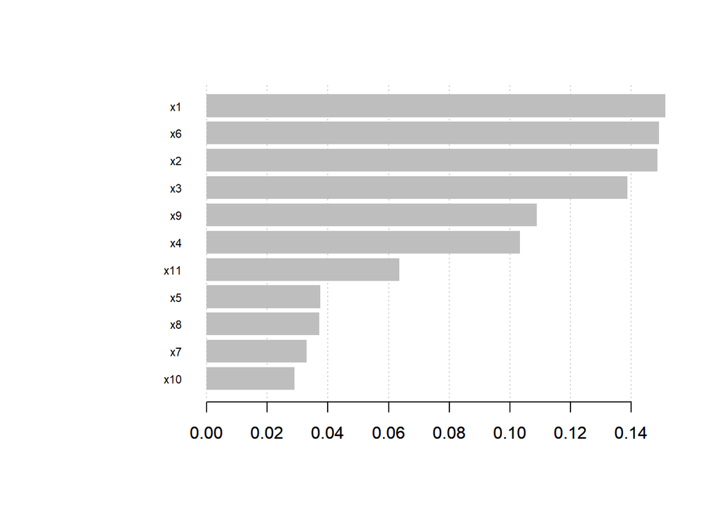

```r
xgb.importance(model = xgb_test) %>%
  xgb.plot.importance(top_n = 11)
```

```r
sim$y <- ifelse(sim$y>0,1,0)
sim_2$y <- ifelse(sim_2$y>0,1,0)
glm(y~.,family = binomial(),data = sim) %>% summary()
```

```
##
## Call:
## glm(formula = y ~ ., family = binomial(), data = sim)
##
## Deviance Residuals:
##     Min       1Q   Median       3Q      Max
## -1.4158  -1.1813   0.9577   1.1559   1.4366
##
## Coefficients:
##              Estimate Std. Error z value Pr(>|z|)
## (Intercept)  0.027156   0.064230   0.423   0.6724
## x1          -0.003969   0.064534  -0.062   0.9510
## x2          -0.062233   0.064346  -0.967   0.3335
## x3          -0.020479   0.063392  -0.323   0.7467
## x4          -0.004233   0.063169  -0.067   0.9466
## x5           0.061103   0.062226   0.982   0.3261
## x6          -0.132396   0.062184  -2.129   0.0332 *
## x7          -0.033800   0.064863  -0.521   0.6023
## x8           0.047522   0.063323   0.750   0.4530
## x9           0.070682   0.067476   1.048   0.2949
## x10          0.079707   0.063363   1.258   0.2084
## x11          0.025417   0.063512   0.400   0.6890
## ---
## Signif. codes:  0 '***' 0.001 '**' 0.01 '*' 0.05 '.' 0.1 ' ' 1
##
## (Dispersion parameter for binomial family taken to be 1)
##
##     Null deviance: 1385.9  on 999  degrees of freedom
## Residual deviance: 1374.8  on 988  degrees of freedom
## AIC: 1398.8
##
## Number of Fisher Scoring iterations: 4
```

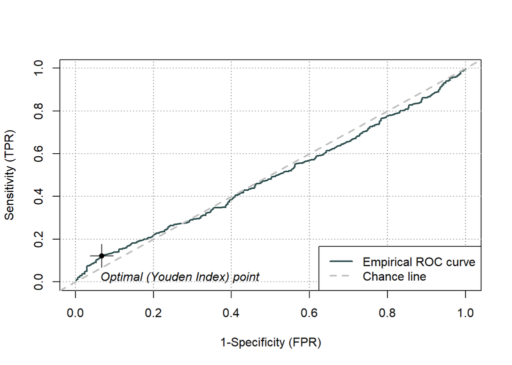

```r
label  <- glm(y~.,family = binomial(),data = sim) %>% predict(sim_2,type="response")
Roc <- rocit(score=label,class=sim_2$y )

plot(Roc,values=F)
```

```r
Cutoff <- which(Roc$FPR>=0.1) %>%
  min %>%
  Roc$Cutoff[.]
table(sim_2$y,label>Cutoff)
```

```
##
##     FALSE TRUE
##   0   429   47
##   1   451   73
```

```r
print("xgboost")
```

```
## [1] "xgboost"
```

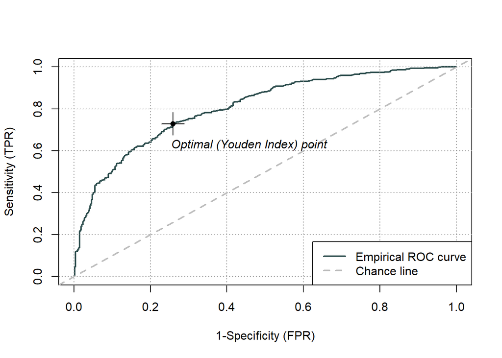

```r
xgb_test <- xgboost(data = data.matrix(sim[,-1]),
label = sim[,"y"],
eta = 0.5,
max_depth = 10,
nround=25,
subsample = 0.7,
colsample_bytree = 0.7,
objective = "binary:logistic",
verbose = 0
)
label  <- predict(xgb_test,xgb.DMatrix(data.matrix(sim_2[,-1])))
Roc <- rocit(score=label,class=sim_2$y )

plot(Roc,values=F)
```

```r
Cutoff <- which(Roc$FPR>=0.25) %>%
  min %>%
  Roc$Cutoff[.]

table(sim_2$y,label>Cutoff)
```

```
##
##     FALSE TRUE
##   0   358  118
##   1   153  371
```

```r
xgb.importance(model = xgb_test)
```

| Feature | Gain | Cover | Frequency |
| --- | --- | --- | --- |
| x6 | 0.12224773 | 0.12106111 | 0.10047847 |
| x3 | 0.10770752 | 0.09270475 | 0.11004785 |
| x5 | 0.10664697 | 0.12077804 | 0.11004785 |
| x4 | 0.10643536 | 0.10690140 | 0.09473684 |
| x2 | 0.10418951 | 0.06359207 | 0.08133971 |
| x7 | 0.09142532 | 0.07330630 | 0.08612440 |
| x8 | 0.08860635 | 0.10903727 | 0.09760766 |
| x11 | 0.07858594 | 0.08772014 | 0.08995215 |
| x9 | 0.07351431 | 0.08403269 | 0.08516746 |
| x1 | 0.06517975 | 0.06790536 | 0.07272727 |

[output cut: 1 more lines]

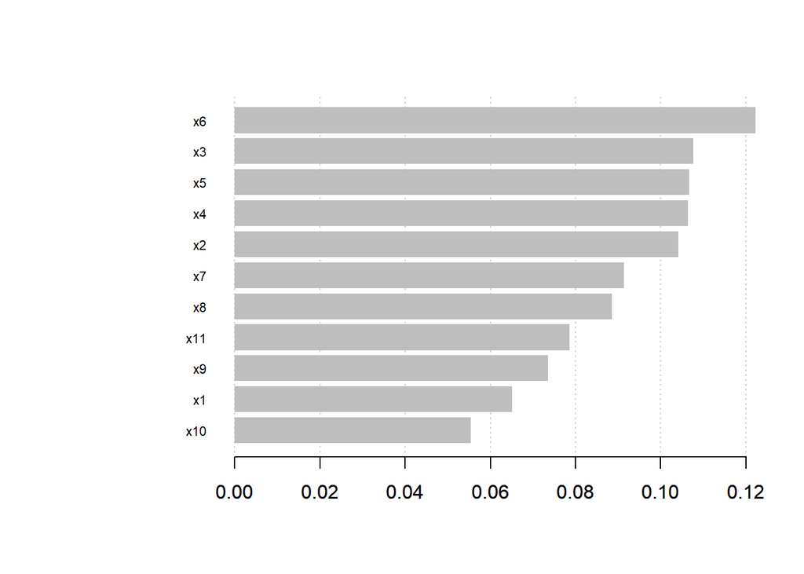

```r
xgb.importance(model = xgb_test) %>%
  xgb.plot.importance(top_n = 11)
```